# EDA_PreProcessing

## library loading

```r
library("readxl")
library("dplyr")
```

```r
library("corrplot")
library("lubridate")
library("tidyverse")
library("reshape")
library("gridExtra")
library("plyr")
library("RColorBrewer")
library("vars")
library("urca")
library("tseries")
library("forecast")
library("data.table")
library("caret")
library("ggcorrplot")
library("extrafont")
```

# 1. EDA

## 전처리

```r
# 데이터 불러오기
data <- read_excel("C:/Users/10sop/Desktop/빅콘테스트/2021 빅콘테스트_데이터분석분야_퓨처스리그_홍수ZERO_댐유입량,강우,수위데이터_210902_update.xlsx")
```

```
## * `` -> ...8
## * `` -> ...9
## * `` -> ...10
## * `` -> ...11
## * `` -> ...12
## * ...
```

```r
# 첫 번째 행 전처리
for( i in 1:42){
  if(i>=1 && i<= 7){
    names(data)[i+6] <- paste(as.character(data[1,i+6]),"_1", sep = "")
  }else if(i>= 8 && i<= 14){
    names(data)[i+6] <- paste(as.character(data[1,i+6]),"_2", sep = "")
  }else if(i >= 15 && i<= 21){
    names(data)[i+6] <- paste(as.character(data[1,i+6]),"_3", sep = "")
  }else if(i >= 22 && i <= 28){
    names(data)[i+6] <- paste(as.character(data[1,i+6]),"_4", sep = "")
  }else if(i >= 29 && i <= 35){
    names(data)[i+6] <- paste(as.character(data[1,i+6]),"_5", sep = "")
  }else if(i >= 36 && i <= 42){
    names(data)[i+6] <- paste(as.character(data[1,i+6]),"_6", sep = "")
  }
}

# 첫 행이 열 이름으로 되어있으므로 삭제
data<- data[-1,]
data %>% str
```

```
## tibble [3,051 x 48] (S3: tbl_df/tbl/data.frame)
##  $ 홍수사상번호  : num [1:3051] 1 1 1 1 1 1 1 1 1 1 ...
##  $ 연            : num [1:3051] 2006 2006 2006 2006 2006 ...
##  $ 월            : num [1:3051] 7 7 7 7 7 7 7 7 7 7 ...
##  $ 일            : num [1:3051] 10 10 10 10 10 10 10 10 10 10 ...
##  $ 시간          : num [1:3051] 8 9 10 11 12 13 14 15 16 17 ...
##  $ 유입량        : num [1:3051] 189 217 251 303 385 ...
##  $ 유역평균강수_1: chr [1:3051] "6.4" "6.3" "6.4" "7.3" ...
##  $ 강우(A지역)_1 : chr [1:3051] "7" "7" "7" "7" ...
##  $ 강우(B지역)_1 : chr [1:3051] "7" "8" "9" "10" ...
##  $ 강우(C지역)_1 : chr [1:3051] "7" "7" "7" "7" ...
##  $ 강우(D지역)_1 : chr [1:3051] "8" "8" "8" "8" ...
##  $ 수위(E지역)_1 : chr [1:3051] "2.54" "2.5299999999999998" "2.5299999999999998" "2.5299999999999998" ...
##  $ 수위(D지역)_1 : chr [1:3051] "122.56874999999999" "122.5625" "122.55625000000001" "122.55625000000001" ...
##  $ 유역평균강수_2: chr [1:3051] "6.3" "6.4" "7.3" "8.1999999999999993" ...
```

[output cut: 34 more lines]

```r
# 연, 월, 일, 시를 character로 바꾸고 나머지 변수를 numeric으로 교체
features <- data[,-c(1:5)]
features <- lapply(features, function(x) as.numeric(x))
data <- cbind(data[,1:5],features)
data[, "연"] <- data[,"연"] %>% as.character
data[, "월"] <- data[,"월"] %>% as.character
data[, "일"] <- data[,"일"] %>% as.character
data[, "시간"] <- data[,"시간"] %>% as.character
data %>% str
```

```
## 'data.frame':    3051 obs. of  48 variables:
##  $ 홍수사상번호  : num  1 1 1 1 1 1 1 1 1 1 ...
##  $ 연            : chr  "2006" "2006" "2006" "2006" ...
##  $ 월            : chr  "7" "7" "7" "7" ...
##  $ 일            : chr  "10" "10" "10" "10" ...
##  $ 시간          : chr  "8" "9" "10" "11" ...
##  $ 유입량        : num  189 217 251 303 385 ...
##  $ 유역평균강수_1: num  6.4 6.3 6.4 7.3 8.2 11.3 14.4 16.9 20.5 25.8 ...
##  $ 강우(A지역)_1 : num  7 7 7 7 7 7 9 12 14 15 ...
##  $ 강우(B지역)_1 : num  7 8 9 10 12 14 17 24 33 40 ...
##  $ 강우(C지역)_1 : num  7 7 7 7 8 10 10 15 18 20 ...
##  $ 강우(D지역)_1 : num  8 8 8 8 10 11 14 16 17 21 ...
##  $ 수위(E지역)_1 : num  2.54 2.53 2.53 2.53 2.53 2.53 2.53 2.54 2.56 2.58 ...
##  $ 수위(D지역)_1 : num  123 123 123 123 123 ...
##  $ 유역평균강수_2: num  6.3 6.4 7.3 8.2 11.3 14.4 16.9 20.5 25.8 31.7 ...
```

[output cut: 34 more lines]

```r
# 시간을 하나의 열로 데이터에 추가
myDate <- paste(data$연, data$월, data$일, data$시간, seq = '') %>% ymd_h()
data <- cbind(data[,1:5] , myDate, data[,-c(1:5)])
colnames(data)[6] <- "time"


# 학습 데이터의 시각화를 위해 홍수사상번호 25번까지만 학습 데이터로 저장
train_data <- data %>% filter(홍수사상번호 <= 25)
test_data <- data %>% filter(홍수사상번호 == 26)
```

## 홍수사상번호별 유입량 그래프

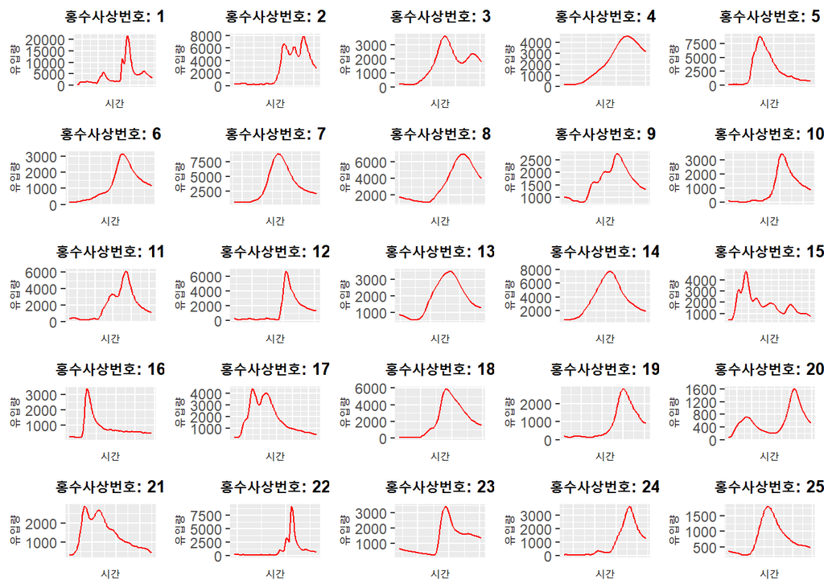

```r
for(i in 1:25){
  num_graph <- train_data %>%
    filter(홍수사상번호 == i) %>%
    ggplot(aes(x= time, y = 유입량)) +
    ggtitle(paste0("홍수사상번호: ", i, sep = "")) +
    geom_line(color = 'red') +
    theme(plot.title = element_text(hjust = 0.5, size = 10, face = "bold"),
          axis.text.x = element_blank(),
          axis.ticks.x = element_blank(),
          axis.title.x = element_text(size = 8),
          axis.title.y = element_text(size = 8)) +
    labs(x = "시간", y = "유입량")
  name <- paste("num_graph",i,sep = "")
  assign(name, num_graph)
}

num_graphs <- mget(paste0("num_graph", 1:25))
grid.arrange(grobs = num_graphs)
```

## 연도별 유입량

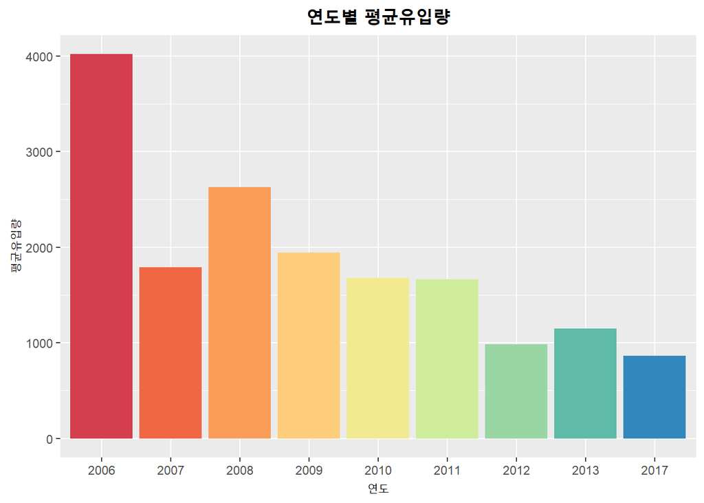

```r
year_count <- length(unique(train_data$연))
year_Palette <- colorRampPalette(brewer.pal(8,"Spectral"))

by_year <- train_data %>%
  group_by(연) %>%
  dplyr::summarise(avg = mean(유입량)) %>%
  ggplot(aes(x = factor(연), y = avg, fill = as.factor(연))) +
  geom_bar(stat = 'identity') +
  labs(x = "연도", y = "평균유입량") +
  ggtitle("연도별 평균유입량") +
  theme(plot.title = element_text(hjust = 0.5, size = 15, face = "bold"),
        legend.position = "none") +
  scale_fill_manual(values = year_Palette(year_count))

by_year
```

## 월별 유입량

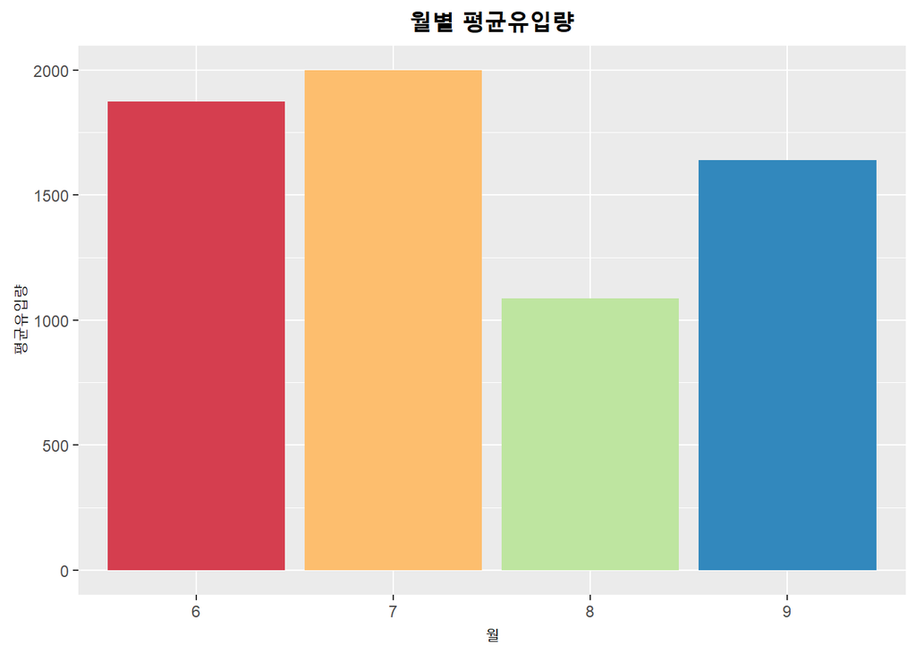

```r
month_count <- length(unique(train_data$월))
month_Palette <- colorRampPalette(brewer.pal(8,"Spectral"))

by_month <- train_data %>%
  group_by(월) %>%
  dplyr::summarise(avg = mean(유입량)) %>%
  ggplot(aes(x = factor(월), y = avg, fill = as.factor(월))) +
  geom_bar(stat = 'identity') +
  labs(x = "월", y = "평균유입량") +
  ggtitle("월별 평균유입량") +
  theme(plot.title = element_text(hjust = 0.5, size = 15, face = "bold"),
        legend.position = "none") +
  scale_fill_manual(values = month_Palette(month_count))

by_month
```

## 일별 유입량

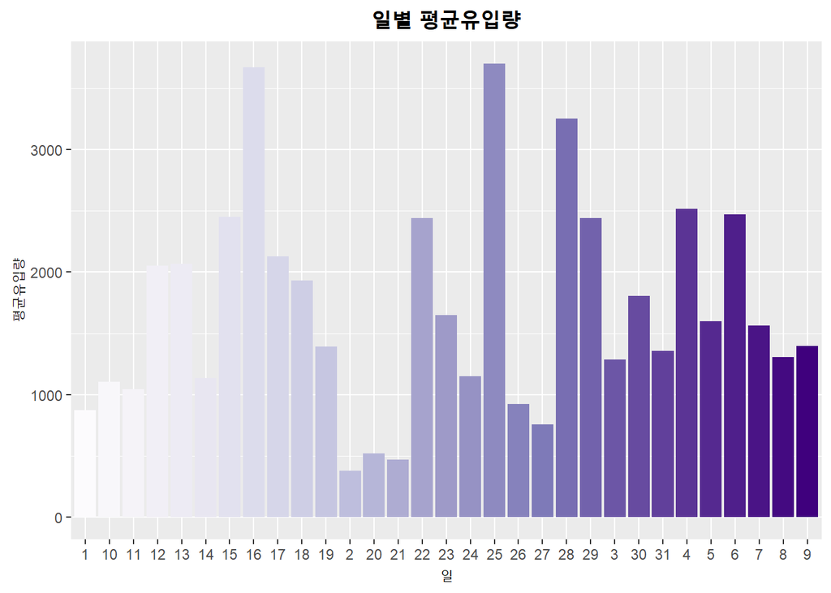

```r
day_count <- length(unique(train_data$일))
day_Palette <- colorRampPalette(brewer.pal(9,"Purples"))

by_day <- train_data %>%
  group_by(일) %>%
  dplyr::summarise(avg = mean(유입량)) %>%
  ggplot(aes(x = factor(일), y = avg, fill = as.factor(일))) +
  geom_bar(stat = 'identity') +
  labs(x = "일", y = "평균유입량") +
  ggtitle("일별 평균유입량") +
  theme(plot.title = element_text(hjust = 0.5, size = 15, face = "bold"),
        legend.position = "none") +
  scale_fill_manual(values = day_Palette(day_count))

by_day
```

## 시간별 유입량

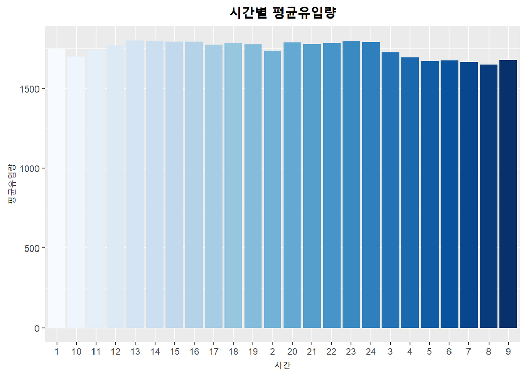

```r
time_count <- length(unique(train_data$시간))
time_Palette <- colorRampPalette(brewer.pal(9,"Blues"))

by_time <- train_data %>%
  group_by(시간) %>%
  dplyr::summarise(avg = mean(유입량)) %>%
  ggplot(aes(x = factor(시간), y = avg, fill = as.factor(시간))) +
  geom_bar(stat = 'identity') +
  labs(x = "시간", y = "평균유입량") +
  ggtitle("시간별 평균유입량") +
  theme(plot.title = element_text(hjust = 0.5, size = 15, face = "bold"),
        legend.position = "none") +
  scale_fill_manual(values = time_Palette(time_count))
by_time
```

## 연도별 Box plot

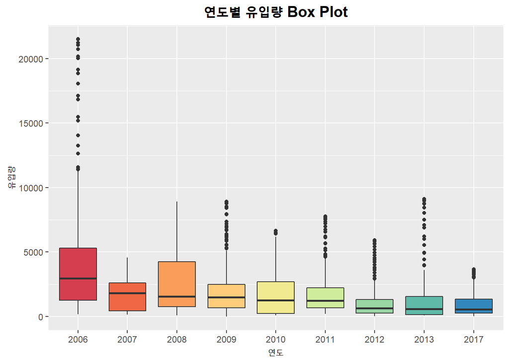

```r
year_Palette <- colorRampPalette(brewer.pal(8,"Spectral"))

year_box <-train_data %>%
  ggplot(aes(x = factor(연), y = 유입량, group = as.factor(연),fill = factor(연))) +
  geom_boxplot() +
  scale_fill_manual(values = year_Palette(year_count)) +
  labs(x = "연도", y = "유입량") +
  ggtitle("연도별 유입량 Box Plot") +
  theme(plot.title = element_text(hjust = 0.5, size = 15, face = "bold"),
        legend.position = "none")

year_box
```

## 월별 Box plot

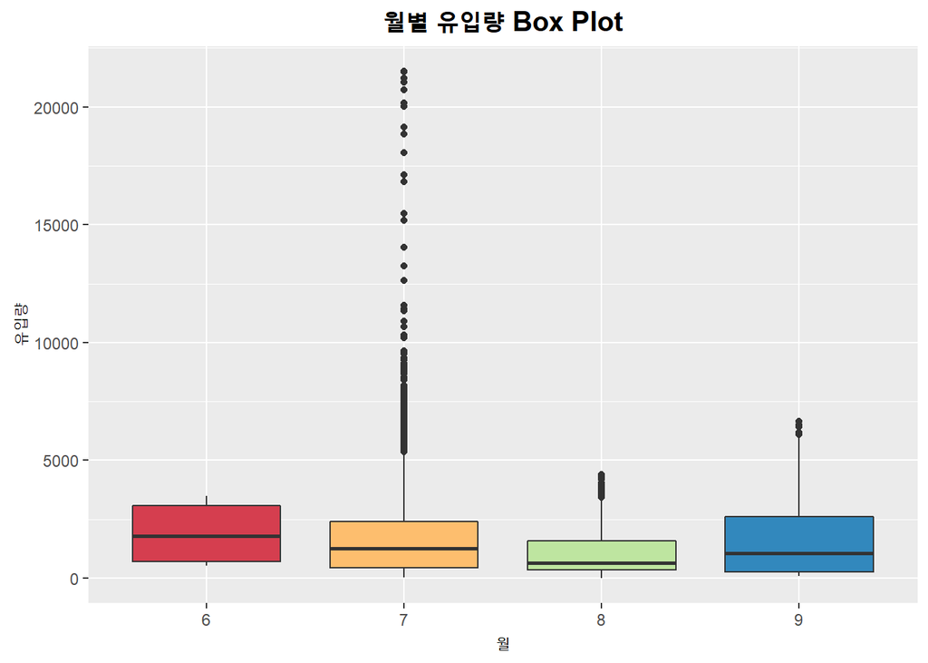

```r
month_Palette <- colorRampPalette(brewer.pal(8,"Spectral"))


month_box <-train_data %>%
  ggplot(aes(x = factor(월), y = 유입량, group = as.factor(월),fill = factor(월))) +
  geom_boxplot() +
  scale_fill_manual(values = month_Palette(month_count)) +
  labs(x = "월", y = "유입량") +
  ggtitle("월별 유입량 Box Plot") +
  theme(plot.title = element_text(hjust = 0.5, size = 15, face = "bold"),
        legend.position = "none")

month_box
```

## y축 조정한 월별 Box plot

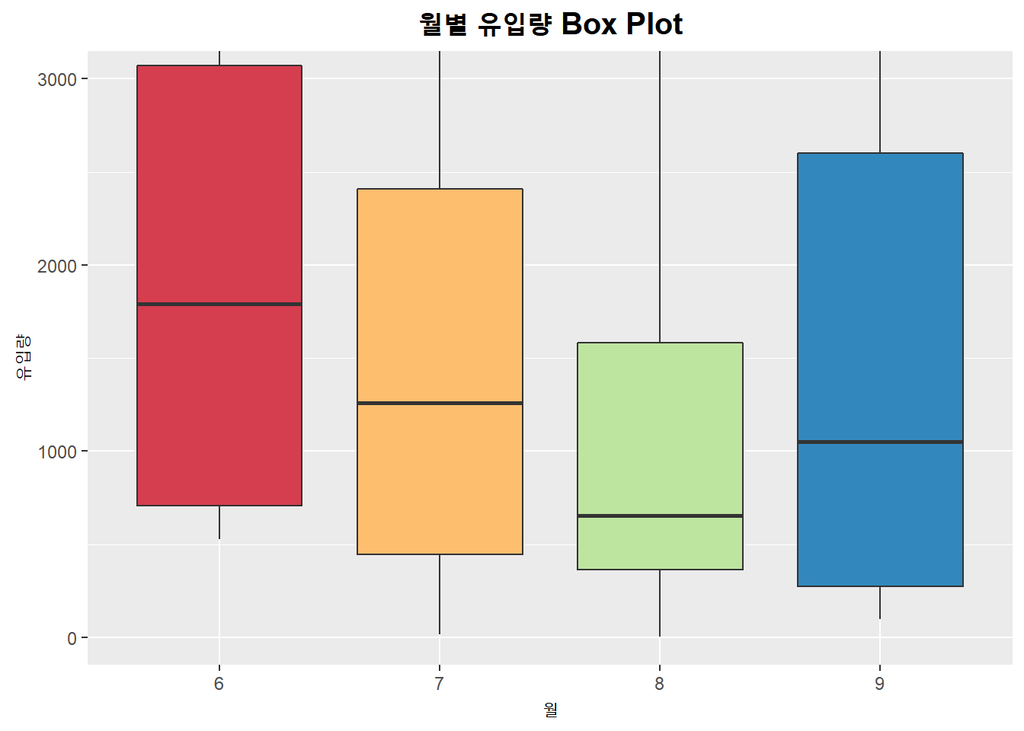

```r
train_data %>%
  ggplot(aes(x = factor(월), y = 유입량, group = as.factor(월),fill = factor(월))) +
  geom_boxplot(outlier.shape = NA) +
  scale_fill_manual(values = month_Palette(month_count)) +
  labs(x = "월", y = "유입량") +
  ggtitle("월별 유입량 Box Plot") +
  theme(plot.title = element_text(hjust = 0.5, size = 15, face = "bold"),
        legend.position = "none") +
  coord_cartesian(ylim = c(0,3000))
```

## 홍수사상번호별 Box plot

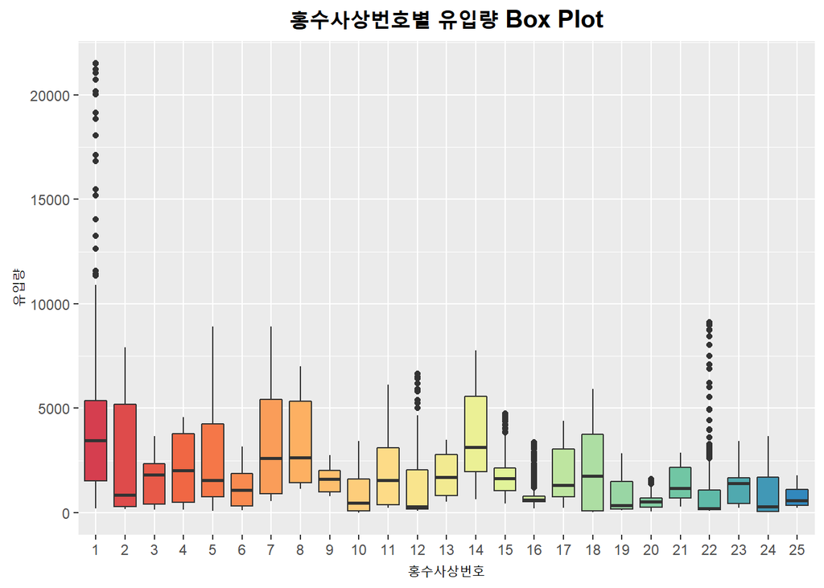

```r
num_count <- length(unique(train_data$홍수사상번호))
num_Palette <- colorRampPalette(brewer.pal(8,"Spectral"))

num_box <-train_data %>%
  ggplot(aes(x = factor(홍수사상번호), y = 유입량, group = as.factor(홍수사상번호),fill = factor(홍수사상번호))) +
  geom_boxplot() +
  scale_fill_manual(values = num_Palette(num_count)) +
  labs(x = "홍수사상번호", y = "유입량") +
  ggtitle("홍수사상번호별 유입량 Box Plot") +
  theme(plot.title = element_text(hjust = 0.5, size = 15, face = "bold"),
        legend.position = "none")

num_box
```

## 집단별 상관관계

```r
corr_data <- train_data
corr_data <- corr_data[,-c(1:7)]
corr_data <- lapply(corr_data, function(x) as.double(x))
corr_data <- as.data.frame(corr_data)

mean_precipitation <- corr_data[,1+c(0:5)*7] # 유역평균강수
area_A_rain <- corr_data[,2+c(0:5)*7] # 강우(A지역)
area_B_rain <- corr_data[,3+c(0:5)*7] # 강우(B지역)
area_C_rain <- corr_data[,4+c(0:5)*7] # 강우(C지역)
area_D_rain <- corr_data[,5+c(0:5)*7] # 강우(D지역)
area_E_level <- corr_data[,6+c(0:5)*7] # 수위(E지역)
area_D_level <- corr_data[,c(1:6)*7] # 수위(D지역)
```

## 각 변수별 그룹간의 상관계수 행렬 생성

```r
# 각 변수별 그룹간의 상관계수 행렬 생성
mean_precipitation_cor <- cor(mean_precipitation)
area_A_rain_cor <- cor(area_A_rain)
area_B_rain_cor <- cor(area_B_rain)
area_C_rain_cor <- cor(area_C_rain)
area_D_rain_cor <- cor(area_D_rain)
area_E_level_cor <- cor(area_E_level)
area_D_level_cor <- cor(area_D_level)

# 상관계수 플랏을 그리는 함수 생성
draw_corr <- function(corr_data) {
  my_plot <- corrplot(corr_data,
           method = 'color',
           type = 'upper',
           addCoef.col = "white",
           tl.pos = "d",
           tl.col = "black",
           tl.cex  = 0.5,
           number.digits = 5,
           number.cex = 0.5)
}
```

## 각 변수별 그룹간의 상관계수 플랏

#### 유역평균강수 상관계수 플랏

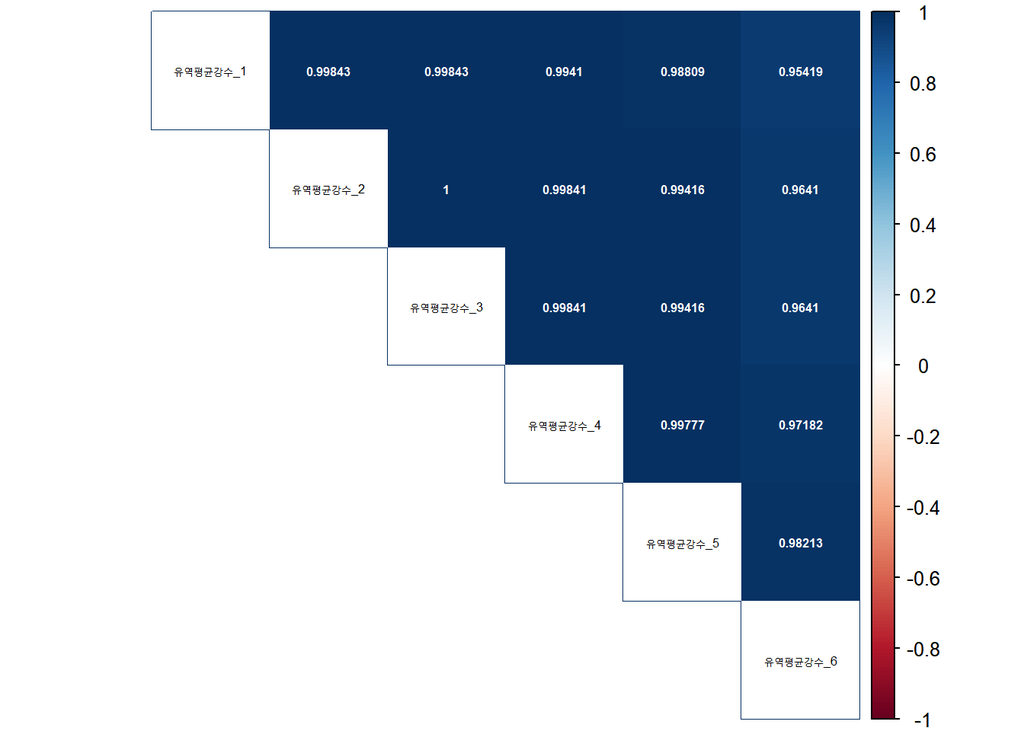

```r
draw_corr(mean_precipitation_cor)
```

#### 강우(A지역) 상관계수 플랏

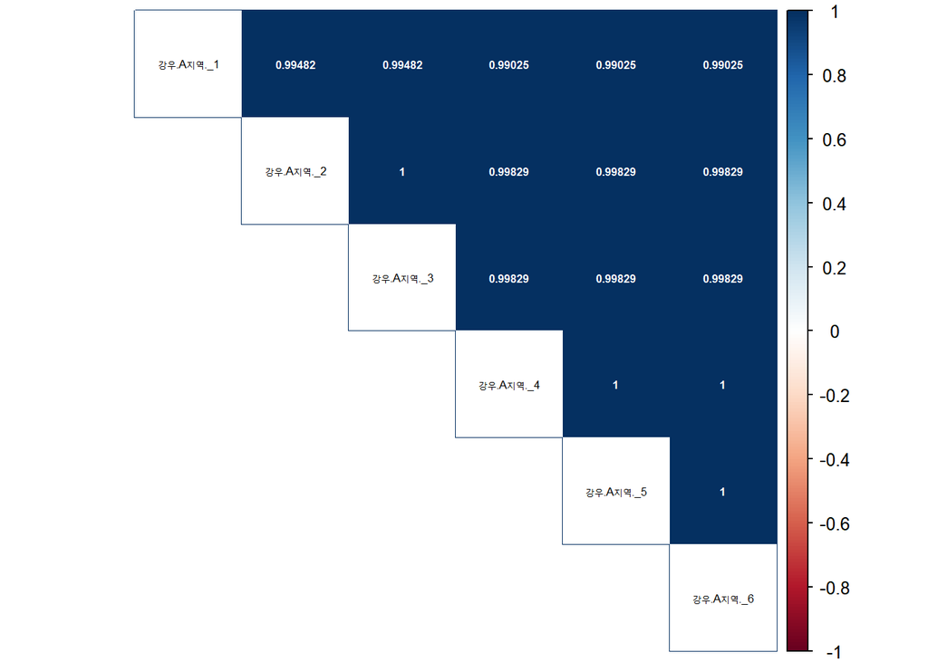

```r
draw_corr(area_A_rain_cor)
```

#### 강우(B지역) 상관계수 플랏

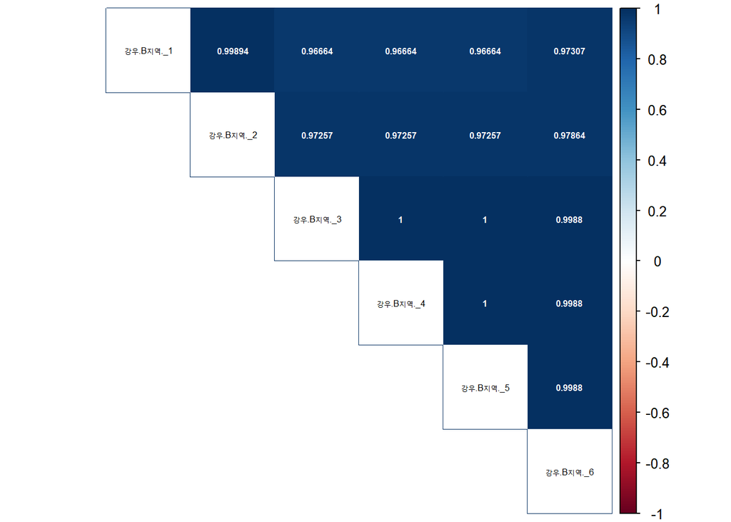

```r
draw_corr(area_B_rain_cor)
```

#### 강우(C지역) 상관계수 플랏

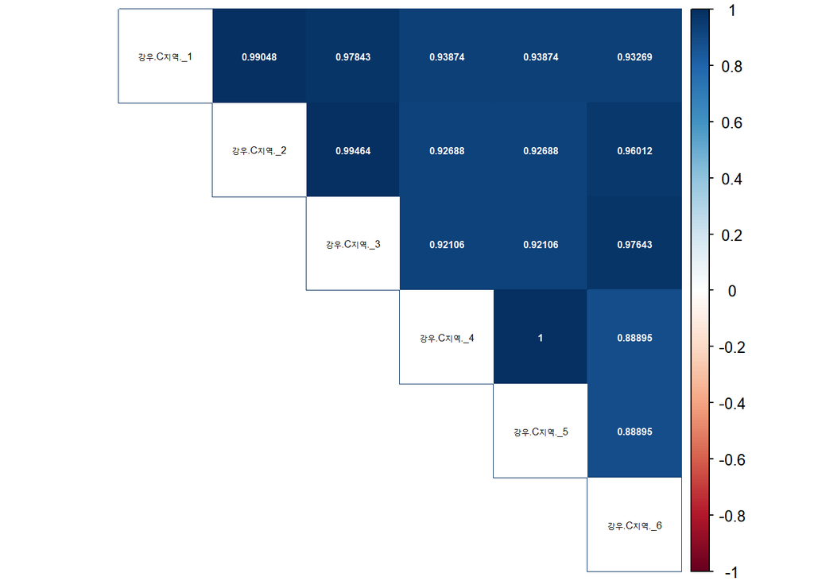

```r
draw_corr(area_C_rain_cor)
```

#### 강우(D지역) 상관계수 플랏

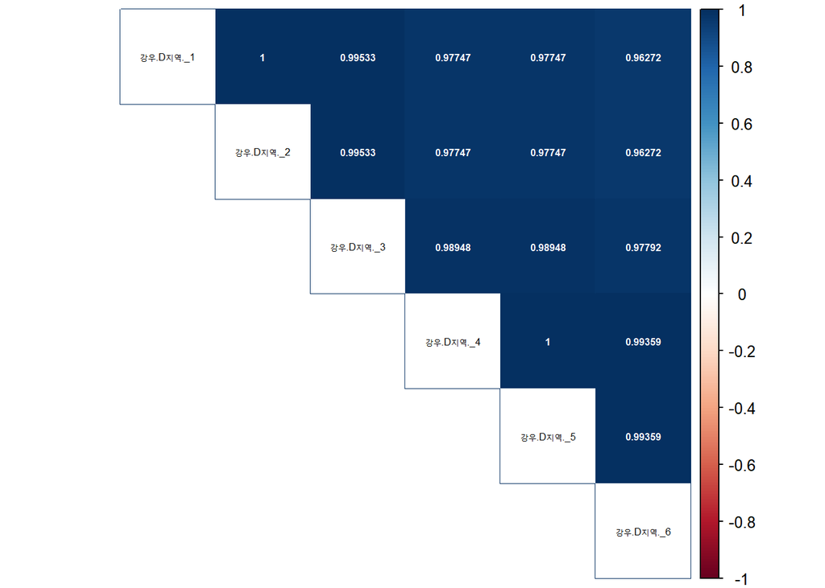

```r
draw_corr(area_D_rain_cor)
```

#### 수위(E지역) 상관계수 플랏

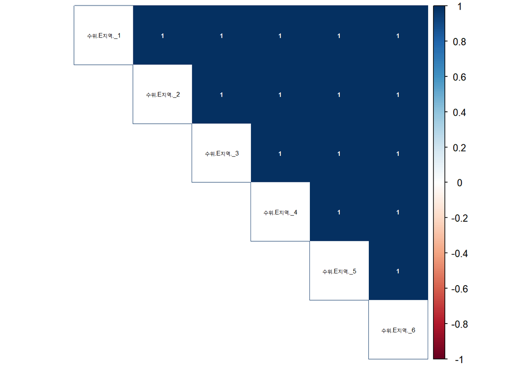

```r
draw_corr(area_E_level_cor)
```

#### 수위(D지역) 상관계수 플랏

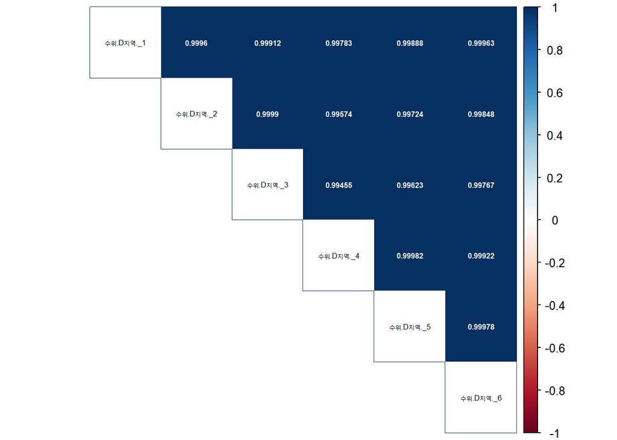

```r
draw_corr(area_D_level_cor)
```

## 수위 변수를 자세히 보기 위해 수위(D지역)과 수위(E지역) 범위 확인

```r
# 각 변수별로 평균값이 필요하므로 평균값을 저장한 데이터 생성
area_D_level_average <- area_D_level %>%
  rowMeans()
area_E_level_average <- area_E_level %>%
  rowMeans()

# 각 변수별 Box Plot 그리기
## 수위D지역의 summary
summary(area_D_level_average)
```

```
##    Min. 1st Qu.  Median    Mean 3rd Qu.    Max.
##   118.7   127.5   133.3   131.8   135.3   143.9
```

```r
## 수위E지역의 summary
summary(area_E_level_average)
```

```
##    Min. 1st Qu.  Median    Mean 3rd Qu.    Max.
##   1.070   2.740   4.080   4.583   5.680  16.720
```

# 2. PCA

## PCA 진행

```r
# PCA 함수 생성
get_PCA <- function(cols) {
  prcomp(cols,
         center = T,
         scale = T)
}

# 각 변수별 PCA 진행
mean_precipitation_pca <- get_PCA(mean_precipitation)
area_A_rain_pca <- get_PCA(area_A_rain)
area_B_rain_pca <- get_PCA(area_B_rain)
area_C_rain_pca <- get_PCA(area_C_rain)
area_D_rain_pca <- get_PCA(area_D_rain)
area_E_level_pca <- get_PCA(area_E_level)
area_D_level_pca <- get_PCA(area_D_level)

# PCA 결과
summary(mean_precipitation_pca)
```

```
## Importance of components:
##                           PC1     PC2     PC3     PC4     PC5       PC6
## Standard deviation     2.4358 0.24571 0.07396 0.02957 0.01373 1.788e-16
## Proportion of Variance 0.9889 0.01006 0.00091 0.00015 0.00003 0.000e+00
## Cumulative Proportion  0.9889 0.99891 0.99982 0.99997 1.00000 1.000e+00
```

```r
summary(area_A_rain_pca)
```

```
## Importance of components:
##                           PC1     PC2     PC3       PC4       PC5       PC6
## Standard deviation     2.4461 0.12153 0.04278 4.696e-16 6.527e-17 1.536e-30
## Proportion of Variance 0.9972 0.00246 0.00030 0.000e+00 0.000e+00 0.000e+00
## Cumulative Proportion  0.9972 0.99970 1.00000 1.000e+00 1.000e+00 1.000e+00
```

```r
summary(area_B_rain_pca)
```

```
## Importance of components:
##                           PC1     PC2     PC3     PC4       PC5       PC6
## Standard deviation     2.4335 0.27640 0.03547 0.02571 2.226e-15 1.003e-22
## Proportion of Variance 0.9869 0.01273 0.00021 0.00011 0.000e+00 0.000e+00
## Cumulative Proportion  0.9869 0.99968 0.99989 1.00000 1.000e+00 1.000e+00
```

```r
summary(area_C_rain_pca)
```

```
## Importance of components:
##                           PC1     PC2    PC3     PC4     PC5      PC6
## Standard deviation     2.3935 0.44457 0.2522 0.08921 0.04529 1.49e-15
## Proportion of Variance 0.9548 0.03294 0.0106 0.00133 0.00034 0.00e+00
## Cumulative Proportion  0.9548 0.98773 0.9983 0.99966 1.00000 1.00e+00
```

```r
summary(area_D_rain_pca)
```

```
## Importance of components:
##                           PC1    PC2     PC3     PC4       PC5       PC6
## Standard deviation     2.4338 0.2604 0.07939 0.04974 3.112e-16 5.733e-17
## Proportion of Variance 0.9872 0.0113 0.00105 0.00041 0.000e+00 0.000e+00
## Cumulative Proportion  0.9872 0.9985 0.99959 1.00000 1.000e+00 1.000e+00
```

```r
summary(area_E_level_pca)
```

```
## Importance of components:
##                          PC1       PC2       PC3       PC4       PC5       PC6
## Standard deviation     2.449 1.015e-14 9.478e-29 1.245e-42 1.317e-56 8.129e-71
## Proportion of Variance 1.000 0.000e+00 0.000e+00 0.000e+00 0.000e+00 0.000e+00
## Cumulative Proportion  1.000 1.000e+00 1.000e+00 1.000e+00 1.000e+00 1.000e+00
```

```r
summary(area_D_level_pca)
```

```
## Importance of components:
##                           PC1     PC2     PC3      PC4      PC5      PC6
## Standard deviation     2.4477 0.09269 0.01286 0.002776 0.001247 0.000674
## Proportion of Variance 0.9985 0.00143 0.00003 0.000000 0.000000 0.000000
## Cumulative Proportion  0.9985 0.99997 1.00000 1.000000 1.000000 1.000000
```

## 변수별 주성분의 설명 분산에 대한 Scree plot

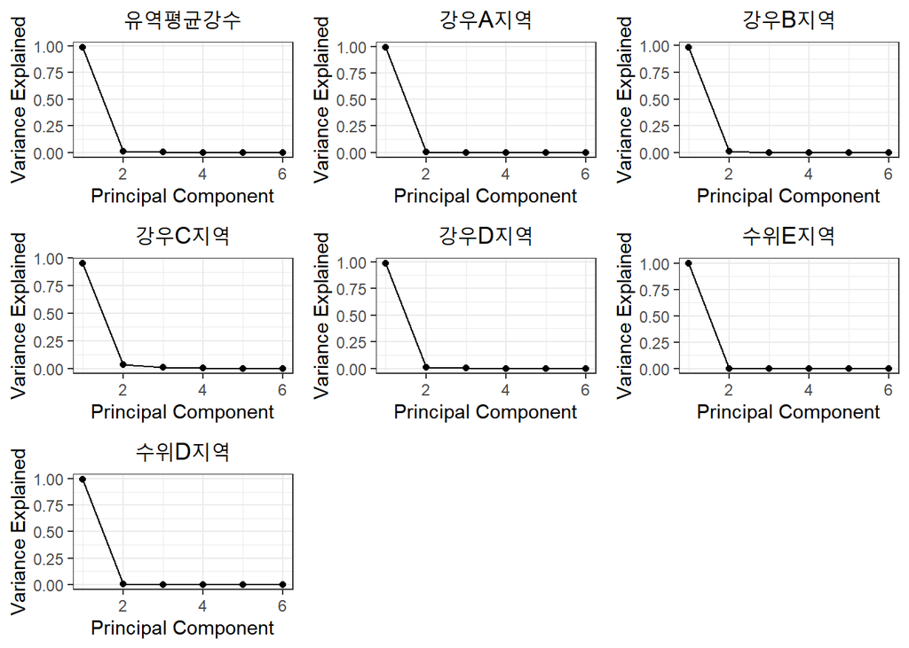

```r
PC_scree_plot <- function(x){
  var_explained = x[["sdev"]]^2/sum(x[["sdev"]]^2)
  plot_frame <- cbind(c(1:6), var_explained) %>% as.data.frame
  colnames(plot_frame)[1] <- "index"
  ggplot(plot_frame,
         aes(x = index,
             y = var_explained))+
    theme_bw()+
    geom_line()+
    geom_point()+
    xlab("Principal Component")+
    ylab("Variance Explained")+
    ggtitle("PC scree plot")+
    theme(plot.title = element_text(hjust = 0.5))
}

grid.arrange(PC_scree_plot(mean_precipitation_pca)+
               ggtitle("유역평균강수"),
             PC_scree_plot(area_A_rain_pca)+
               ggtitle("강우A지역"),
             PC_scree_plot(area_B_rain_pca)+
               ggtitle("강우B지역"),
             PC_scree_plot(area_C_rain_pca)+
               ggtitle("강우C지역"),
             PC_scree_plot(area_D_rain_pca)+
               ggtitle("강우D지역"),
             PC_scree_plot(area_E_level_pca)+
               ggtitle("수위E지역"),
             PC_scree_plot(area_D_level_pca)+
               ggtitle("수위D지역")
             )
```

PC1의 설명분산이 대부분을 차지하므로 모든 X변수에서 PC1만 선택

## PCA 결과를 데이터프레임화

```r
pca_train <- cbind(train_data[1:7],
                   mean_precipitation_pca[["x"]][,"PC1"],
                   area_A_rain_pca[["x"]][,"PC1"],
                   area_B_rain_pca[["x"]][,"PC1"],
                   area_C_rain_pca[["x"]][,"PC1"],
                   area_D_rain_pca[["x"]][,"PC1"],
                   area_E_level_pca[["x"]][,"PC1"],
                   area_D_level_pca[["x"]][,"PC1"])

colnames(pca_train) <- c("홍수사상번호",
                         "연",
                         "월",
                         "일",
                         "시간",
                         "datetime",
                         "유입량",
                         "유역평균강수",
                         "강우(A지역)",
                         "강우(B지역)",
                         "강우(C지역)",
                         "강우(D지역)",
                         "수위(E지역)",
                         "수위(D지역)")
pca_train %>% head
```

```
##   홍수사상번호   연 월 일 시간            datetime   유입량 유역평균강수
## 1            1 2006  7 10    8 2006-07-10 08:00:00 189.1000    -2.515498
## 2            1 2006  7 10    9 2006-07-10 09:00:00 216.9520    -2.496035
## 3            1 2006  7 10   10 2006-07-10 10:00:00 251.4244    -2.464320
## 4            1 2006  7 10   11 2006-07-10 11:00:00 302.8122    -2.381279
## 5            1 2006  7 10   12 2006-07-10 12:00:00 384.7834    -2.268271
## 6            1 2006  7 10   13 2006-07-10 13:00:00 512.5012    -2.152866
##   강우(A지역) 강우(B지역) 강우(C지역) 강우(D지역) 수위(E지역) 수위(D지역)
## 1   -2.529901   -2.080793   -1.846718   -1.992287   -2.065840   -3.771849
## 2   -2.529901   -2.041185   -1.797621   -1.949197   -2.075951   -3.773126
## 3   -2.529901   -2.001576   -1.788507   -1.927651   -2.075951   -3.774403
## 4   -2.496948   -1.961968   -1.638417   -1.848563   -2.075951   -3.775188
## 5   -2.425388   -1.882752   -1.537565   -1.769502   -2.075951   -3.777365
## 6   -2.359240   -1.803535   -1.433990   -1.711905   -2.075951   -3.779836
```

## 학습 데이터로 PCA적용한 것을 시험 데이터에 적용

```r
for_test_pca <- test_data[,-c(1:7)]
for_test_pca <- lapply(for_test_pca, function(x) as.double(x))

for_test_pca <- as.data.frame(for_test_pca)

mean_precipitation_test <- for_test_pca[,1+c(0:5)*7] # 유역평균강수
area_A_rain_test <- for_test_pca[,2+c(0:5)*7] # 강우(A지역)
area_B_rain_test <- for_test_pca[,3+c(0:5)*7] # 강우(B지역)
area_C_rain_test <- for_test_pca[,4+c(0:5)*7] # 강우(C지역)
area_D_rain_test <- for_test_pca[,5+c(0:5)*7] # 강우(D지역)
area_E_level_test <- for_test_pca[,6+c(0:5)*7] # 수위(E지역)
area_D_level_test <- for_test_pca[,c(1:6)*7] # 수위(D지역)

mean_precipitation_pca_test <- predict(mean_precipitation_pca, mean_precipitation_test)
area_A_rain_pca_test <- predict(area_A_rain_pca, area_A_rain_test)
area_B_rain_pca_test <- predict(area_B_rain_pca, area_B_rain_test)
area_C_rain_pca_test <- predict(area_C_rain_pca, area_C_rain_test)
area_D_rain_pca_test <- predict(area_D_rain_pca, area_D_rain_test)
area_E_level_pca_test <- predict(area_E_level_pca, area_E_level_test)
area_D_level_pca_test <- predict(area_D_level_pca, area_D_level_test)

pca_test <- cbind(test_data[1:7],
                   mean_precipitation_pca_test[,"PC1"],
                   area_A_rain_pca_test[,"PC1"],
                   area_B_rain_pca_test[,"PC1"],
                   area_C_rain_pca_test[,"PC1"],
                   area_D_rain_pca_test[,"PC1"],
                   area_E_level_pca_test[,"PC1"],
                   area_D_level_pca_test[,"PC1"])

colnames(pca_test) <- colnames(pca_train)

pca_test %>% head
```

```
##   홍수사상번호   연 월 일 시간            datetime 유입량 유역평균강수
## 1           26 2018  7  1    6 2018-07-01 06:00:00     NA    -2.464289
## 2           26 2018  7  1    7 2018-07-01 07:00:00     NA    -2.472915
## 3           26 2018  7  1    8 2018-07-01 08:00:00     NA    -2.341616
## 4           26 2018  7  1    9 2018-07-01 09:00:00     NA    -2.126982
## 5           26 2018  7  1   10 2018-07-01 10:00:00     NA    -1.853566
## 6           26 2018  7  1   11 2018-07-01 11:00:00     NA    -1.558066
##   강우(A지역) 강우(B지역) 강우(C지역) 강우(D지역) 수위(E지역) 수위(D지역)
## 1   -1.701748  -2.3580503   -2.208967  -2.3374387   -2.682637   -4.628955
## 2   -2.082785  -2.3184421   -1.889835  -2.1650769   -2.682637   -4.630236
## 3   -2.221565  -2.1600093   -1.757978  -1.8203533   -2.692748   -4.631517
## 4   -2.304607  -1.9223600   -1.556733  -1.5686370   -2.692748   -4.632798
## 5   -2.210745  -1.3678452   -1.359102  -1.2734022   -2.692748   -4.633088
## 6   -2.105400  -0.4568565   -1.120478  -0.9568607   -2.662414   -4.632811
```

## PCA된 각 변수와 유입량 간의 산점도

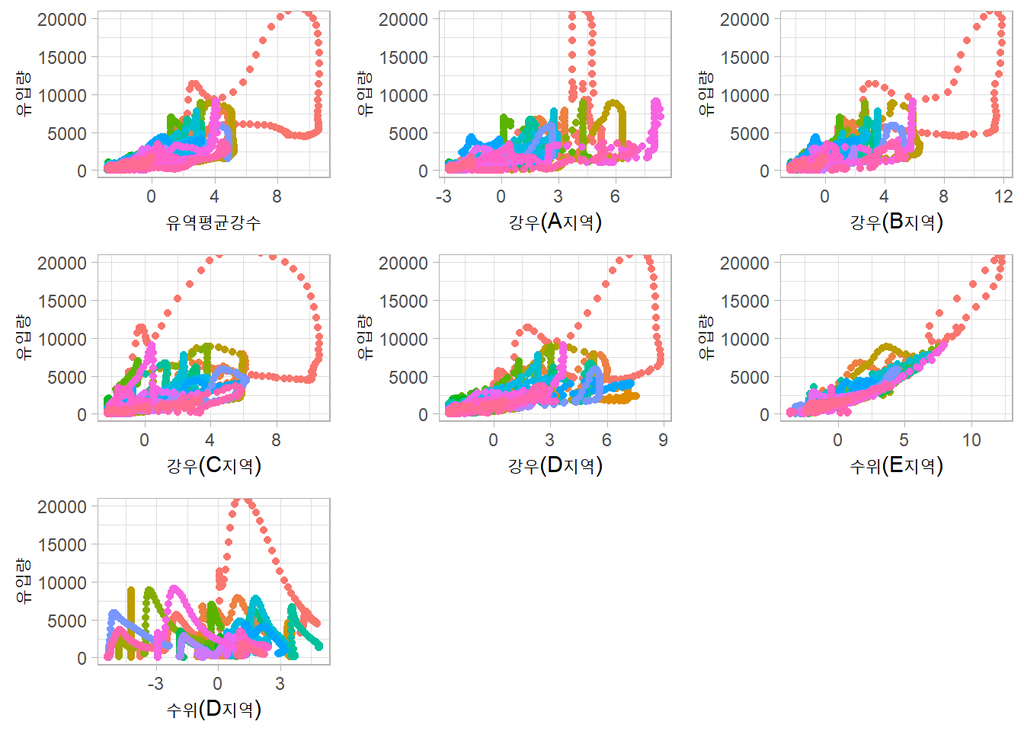

```r
scatter_data <- pca_train

# 유역평균강수와 유입량 Scatter Plot
scatter_mean_precipitation <- ggplot(scatter_data,
       aes(x = 유역평균강수, y = 유입량, color = as.factor(홍수사상번호))) +
  geom_point() +
  theme_light()+
  labs(color = "홍수사상번호") +
  theme(legend.position = "none")+
  coord_cartesian(ylim = c(0, 20000))

# 강우(A지역)과 유입량 Scatter Plot
scatter_a_rain<- ggplot(scatter_data,
       aes(x = `강우(A지역)`, y = 유입량, color = as.factor(홍수사상번호))) +
  geom_point() +
  theme_light()+
  labs(color = "홍수사상번호") +
  theme(legend.position = "none")+
  coord_cartesian(ylim = c(0, 20000))

# 강우(B지역)과 유입량 Scatter Plot
scatter_b_rain <- ggplot(scatter_data,
       aes(x = `강우(B지역)`, y = 유입량, color = as.factor(홍수사상번호))) +
  geom_point() +
  labs(color = "홍수사상번호") +
  theme_light()+
  theme(legend.position = "none")+
  coord_cartesian(ylim = c(0, 20000))

# 강우(C지역)과 유입량 Scatter Plot
scatter_c_rain <- ggplot(scatter_data,
       aes(x = `강우(C지역)`, y = 유입량, color = as.factor(홍수사상번호))) +
  geom_point() +
  labs(color = "홍수사상번호") +
  theme_light()+
  theme(legend.position = "none")+
  coord_cartesian(ylim = c(0, 20000))

# 강우(D지역)과 유입량 Scatter Plot
scatter_d_rain <- ggplot(scatter_data,
       aes(x = `강우(D지역)`, y = 유입량, color = as.factor(홍수사상번호))) +
  geom_point() +
  theme_light()+
  labs(color = "홍수사상번호") +
  theme(legend.position = "none")+
  coord_cartesian(ylim = c(0, 20000))

# 수위(E지역)과 유입량 Scatter Plot
scatter_e_level <- ggplot(scatter_data,
       aes(x = `수위(E지역)`, y = 유입량, color = as.factor(홍수사상번호))) +
  geom_point() +
  theme_light()+
  labs(color = "홍수사상번호") +
  theme(legend.position = "none")+
  coord_cartesian(ylim = c(0, 20000))

# 수위(D지역)과 유입량 Scatter Plot
scatter_d_level <- ggplot(scatter_data,
       aes(x = `수위(D지역)`, y = 유입량, color = as.factor(홍수사상번호))) +
  geom_point() +
  theme_light()+
  labs(color = "홍수사상번호") +
  theme(legend.position = "none")+
  coord_cartesian(ylim = c(0, 20000))

# 한 번에 그리기
grid.arrange(scatter_mean_precipitation,
             scatter_a_rain,
             scatter_b_rain,
             scatter_c_rain,
             scatter_d_rain,
             scatter_e_level,
             scatter_d_level)
```

1번 홍수사상이 이상치로 보임

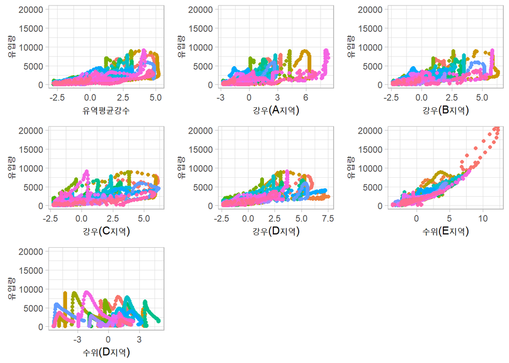

```r
scatter_data_not1 <- pca_train
scatter_data_not1 <- scatter_data_not1[which(scatter_data_not1[, "홍수사상번호"] != 1), ]

# 유역평균강수와 유입량 Scatter Plot
scatter_mean_precipitation <- ggplot(scatter_data_not1,
                                     aes(x = 유역평균강수, y = 유입량, color = as.factor(홍수사상번호))) +
  geom_point() +
  theme_light() +
  labs(color = "홍수사상번호") +
  theme(legend.position = "none")+
  coord_cartesian(ylim = c(0, 20000))

# 강우(A지역)과 유입량 Scatter Plot
scatter_a_rain<- ggplot(scatter_data_not1,
                        aes(x = `강우(A지역)`, y = 유입량, color = as.factor(홍수사상번호))) +
  geom_point() +
  theme_light() +
  labs(color = "홍수사상번호") +
  theme(legend.position = "none")+
  coord_cartesian(ylim = c(0, 20000))

# 강우(B지역)과 유입량 Scatter Plot
scatter_b_rain <- ggplot(scatter_data_not1,
                         aes(x = `강우(B지역)`, y = 유입량, color = as.factor(홍수사상번호))) +
  geom_point() +
  theme_light() +
  labs(color = "홍수사상번호") +
  theme(legend.position = "none")+
  coord_cartesian(ylim = c(0, 20000))

# 강우(C지역)과 유입량 Scatter Plot
scatter_c_rain <- ggplot(scatter_data_not1,
                         aes(x = `강우(C지역)`, y = 유입량, color = as.factor(홍수사상번호))) +
  geom_point() +
  theme_light() +
  labs(color = "홍수사상번호") +
  theme(legend.position = "none")+
  coord_cartesian(ylim = c(0, 20000))

# 강우(D지역)과 유입량 Scatter Plot
scatter_d_rain <- ggplot(scatter_data_not1,
                         aes(x = `강우(D지역)`, y = 유입량, color = as.factor(홍수사상번호))) +
  geom_point() +
  theme_light() +
  labs(color = "홍수사상번호") +
  theme(legend.position = "none")+
  coord_cartesian(ylim = c(0, 20000))

# 수위(E지역)과 유입량 Scatter Plot
scatter_e_level <- ggplot(scatter_data,
                          aes(x = `수위(E지역)`, y = 유입량, color = as.factor(홍수사상번호))) +
  geom_point() +
  theme_light() +
  labs(color = "홍수사상번호") +
  theme(legend.position = "none")+
  coord_cartesian(ylim = c(0, 20000))

# 수위(D지역)과 유입량 Scatter Plot
scatter_d_level <- ggplot(scatter_data_not1,
                          aes(x = `수위(D지역)`, y = 유입량, color = as.factor(홍수사상번호))) +
  geom_point() +
  theme_light()+
  labs(color = "홍수사상번호") +
  theme(legend.position = "none")+
  coord_cartesian(ylim = c(0, 20000))

# 한 번에 그리기
grid.arrange(scatter_mean_precipitation,
             scatter_a_rain,
             scatter_b_rain,
             scatter_c_rain,
             scatter_d_rain,
             scatter_e_level,
             scatter_d_level)
```

# 3. 충격반응분석

## 충격반응분석 전 전처리

```r
copy_data <- pca_train

# 이상치로 보이는 1번 홍수사상 삭제
pca_train <- pca_train[which(pca_train[, "홍수사상번호"] != 1), ]

# Y변수와 X변수 정상성 검정
pca_train[,"유입량"] %>% kpss.test
```

```
##
##  KPSS Test for Level Stationarity
##
## data:  .
## KPSS Level = 2.4503, Truncation lag parameter = 9, p-value = 0.01
```

```r
pca_train[,"유역평균강수"] %>% kpss.test
```

```
##
##  KPSS Test for Level Stationarity
##
## data:  .
## KPSS Level = 1.4877, Truncation lag parameter = 9, p-value = 0.01
```

```r
pca_train[,"강우(A지역)"] %>% kpss.test
```

```
##
##  KPSS Test for Level Stationarity
##
## data:  .
## KPSS Level = 1.2454, Truncation lag parameter = 9, p-value = 0.01
```

```r
pca_train[,"강우(B지역)"] %>% kpss.test
```

```
##
##  KPSS Test for Level Stationarity
##
## data:  .
## KPSS Level = 0.93576, Truncation lag parameter = 9, p-value = 0.01
```

```r
pca_train[,"강우(C지역)"] %>% kpss.test
```

```
##
##  KPSS Test for Level Stationarity
##
## data:  .
## KPSS Level = 1.115, Truncation lag parameter = 9, p-value = 0.01
```

```r
pca_train[,"강우(D지역)"] %>% kpss.test
```

```
##
##  KPSS Test for Level Stationarity
##
## data:  .
## KPSS Level = 1.5957, Truncation lag parameter = 9, p-value = 0.01
```

```r
pca_train[,"수위(D지역)"] %>% kpss.test
```

```
##
##  KPSS Test for Level Stationarity
##
## data:  .
## KPSS Level = 1.5589, Truncation lag parameter = 9, p-value = 0.01
```

```r
pca_train[,"수위(E지역)"] %>% kpss.test
```

```
##
##  KPSS Test for Level Stationarity
##
## data:  .
## KPSS Level = 2.5453, Truncation lag parameter = 9, p-value = 0.01
```

모든 X변수와 Y변수가 귀무가설이 “주어진 시계열은 정상적 시계열”인 정상성 검정인 KPSS test에서 귀무가설을 기각

모든 X변수와 Y변수는 비정상적 시계열이라고 할 수 있음

## X, Y변수 정상화

충격반응분석을 진행하기 위해서 정상화 과정을 거쳐야 하며, 분산이 비교적 큰 댐 유입량 변수는 BoxCox 변환을 통해 분산을 안정화시킨 후 차분, 유역평균강수 변수는 2차 차분, 그 외 강우, 수위 변수는 1차 차분을 하여 정상화 과정 진행

주어진 데이터를 그대로 차분할 경우 홍수사상의 경계에 있는 데이터는 서로다른 홍수사상에서의 데이터끼리 차분하게 되므로, 홍수사상별로 차분하여 하나의 데이터프레임으로 다시 합치는 과정으로 정상화 진행

각 홍수사상 데이터의 경계에 NA행을 넣고 차분한다면 서로 다른 홍수사상의 데이터끼리 차분되는 경우를 방지할 수 있음

```r
# BoxCox 변환을 통해 Y변수 분산안정화
copy_data[, "유입량"] <- BoxCox(copy_data[,"유입량"], lambda = 'auto')

# 홍수사상별로 리스트에 분리해서 입력
myList <- list()
for (i in 2:25) {
  frame_to_list <- copy_data[which(copy_data[, "홍수사상번호"] == i), c("홍수사상번호", "유입량","유역평균강수", "강우(A지역)", "강우(B지역)",
                                                                     "강우(C지역)", "강우(D지역)", "수위(E지역)","수위(D지역)")]
  myList[[i]] <- frame_to_list
}

# 홍수사상별로 들어가있는 리스트에서 하나의 사상씩 데이터를 꺼내오며 홍수사상 사이엔 하나의 NA행을 부착
final_frame <- data.frame()
for (i in 2:25){
  final_frame <- rbind(final_frame, NA, myList[[i]])
}

# 유역평균강수 변수는 다른 변수와는 다르게 2차 차분을 통해 정상화를 진행해야 하므로 미리 1차 차분 진행
spare <- final_frame[, "홍수사상번호"]
num <- final_frame[, "홍수사상번호"]

mean_flood_second_diff <- final_frame[, c("홍수사상번호", "유역평균강수")]

# 각 홍수사상 사이에 NA행이 존재하여 차분하면 홍수사상 경계에서의 차분은 NA처리됨
mean_flood_second_diff <- mean_flood_second_diff %>% as.matrix %>% diff

# NA가 두개씩 생겨야 하는데 맨 앞 NA 하나가 삭제되므로 길이 맞춰주기 위해 제일 처음 행에 NA행 추가
mean_flood_second_diff <- rbind(NA, mean_flood_second_diff)

final_frame[,"유역평균강수"] <- mean_flood_second_diff[,"유역평균강수"]

# 홍수사상번호를 제외한 모든 변수를 차분한 후 하나의 데이터프레임으로 결합
final_frame <- final_frame %>% apply(2, diff)
final_frame <- final_frame[complete.cases(final_frame), ] %>% as.data.frame
num_diff <- c(NA, num %>% diff) %>% diff

# 홍수사상번호는 차분 되면 안 되므로 분리해주고 나중에 결합
good_spare <- spare[num_diff == 0] %>% na.omit %>% as.data.frame
final_frame <- cbind(good_spare ,final_frame[, "유입량"],final_frame[, 3:9])
colnames(final_frame)[c(1,2)] <- c("홍수사상번호","유입량")
final_frame %>% head
```

```
##     홍수사상번호      유입량 유역평균강수 강우(A지역) 강우(B지역) 강우(C지역)
## 229            2 -0.28046766  0.012286980  0.02754148   0.0000000  0.03366249
## 230            2 -0.32780896  0.011011396  0.07697159   0.0396082  0.04278130
## 231            2 -0.05174703  0.004764353  0.13222729   0.0396082  0.02720123
## 232            2  0.24133833 -0.008398343  0.06090855   0.0000000  0.05174983
## 233            2  0.38909013 -0.019329363  0.02233860   0.0396082  0.01808734
## 234            2  0.29826630  0.003042551  0.02792326   0.0000000  0.06717962
##     강우(D지역) 수위(E지역)  수위(D지역)
## 229  0.02154522 -0.01011142 -0.009036481
## 230  0.02877139 -0.01011142 -0.008611463
## 231  0.04314394 -0.01011142 -0.008339005
## 232  0.06468916  0.00000000 -0.007772898
## 233  0.02159872  0.00000000 -0.008288564
## 234  0.05037011  0.00000000 -0.009036488
```

## 정상성 검정

```r
final_frame[,"유입량"] %>% kpss.test
```

```
##
##  KPSS Test for Level Stationarity
##
## data:  .
## KPSS Level = 0.24619, Truncation lag parameter = 9, p-value = 0.1
```

```r
final_frame[,"유역평균강수"] %>% kpss.test
```

```
##
##  KPSS Test for Level Stationarity
##
## data:  .
## KPSS Level = 0.0077896, Truncation lag parameter = 9, p-value = 0.1
```

```r
final_frame[,"강우(A지역)"] %>% kpss.test
```

```
##
##  KPSS Test for Level Stationarity
##
## data:  .
## KPSS Level = 0.30973, Truncation lag parameter = 9, p-value = 0.1
```

```r
final_frame[,"강우(B지역)"] %>% kpss.test
```

```
##
##  KPSS Test for Level Stationarity
##
## data:  .
## KPSS Level = 0.31462, Truncation lag parameter = 9, p-value = 0.1
```

```r
final_frame[,"강우(C지역)"] %>% kpss.test
```

```
##
##  KPSS Test for Level Stationarity
##
## data:  .
## KPSS Level = 0.21767, Truncation lag parameter = 9, p-value = 0.1
```

```r
final_frame[,"강우(D지역)"] %>% kpss.test
```

```
##
##  KPSS Test for Level Stationarity
##
## data:  .
## KPSS Level = 0.3317, Truncation lag parameter = 9, p-value = 0.1
```

```r
final_frame[,"수위(D지역)"] %>% kpss.test
```

```
##
##  KPSS Test for Level Stationarity
##
## data:  .
## KPSS Level = 0.11213, Truncation lag parameter = 9, p-value = 0.1
```

```r
final_frame[,"수위(E지역)"] %>% kpss.test
```

```
##
##  KPSS Test for Level Stationarity
##
## data:  .
## KPSS Level = 0.16158, Truncation lag parameter = 9, p-value = 0.1
```

KPSS test를 진행하였을 때 모든 변수의 p-value가 0.05보다 크므로 귀무가설을 기각하지 못하여 변수들이 정상화 되었음을 확인

## VAR 모델 적합

```r
VARselect(final_frame,lag.max=20,type="const")
```

```
## $selection
## AIC(n)  HQ(n)  SC(n) FPE(n)
##     10      5      2     10
##
## $criteria
##                    1             2             3             4             5
## AIC(n) -4.946039e+01 -5.022112e+01 -5.035130e+01 -5.048879e+01 -5.059763e+01
## HQ(n)  -4.938678e+01 -5.008126e+01 -5.014518e+01 -5.021643e+01 -5.025902e+01
## SC(n)  -4.925724e+01 -4.983513e+01 -4.978247e+01 -4.973712e+01 -4.966313e+01
## FPE(n)  3.308454e-22  1.546124e-22  1.357415e-22  1.183053e-22  1.061064e-22
##                    6             7             8             9            10
## AIC(n) -5.065841e+01 -5.070423e+01 -5.072860e+01 -5.076737e+01 -5.078646e+01
## HQ(n)  -5.025355e+01 -5.023312e+01 -5.019124e+01 -5.016375e+01 -5.011659e+01
## SC(n)  -4.954107e+01 -4.940405e+01 -4.924558e+01 -4.910151e+01 -4.893776e+01
## FPE(n)  9.985188e-23  9.538291e-23  9.309052e-23  8.955557e-23  8.786852e-23
##                   11            12            13            14            15
## AIC(n) -5.077472e+01 -5.078385e+01 -5.078324e+01 -5.077454e+01 -5.076282e+01
## HQ(n)  -5.003860e+01 -4.998148e+01 -4.991462e+01 -4.983967e+01 -4.976170e+01
## SC(n)  -4.874318e+01 -4.856948e+01 -4.838603e+01 -4.819449e+01 -4.799993e+01
## FPE(n)  8.891349e-23  8.811416e-23  8.817884e-23  8.896120e-23  9.002489e-23
##                   16            17            18            19            20
## AIC(n) -5.073883e+01 -5.071973e+01 -5.072006e+01 -5.069761e+01 -5.068174e+01
## HQ(n)  -4.967146e+01 -4.958611e+01 -4.952019e+01 -4.943149e+01 -4.934937e+01
## SC(n)  -4.779310e+01 -4.759117e+01 -4.740866e+01 -4.720337e+01 -4.700466e+01
## FPE(n)  9.222725e-23  9.402507e-23  9.401635e-23  9.617595e-23  9.774258e-23
```

```r
VAR <- VAR(final_frame, p = 2, type= "const")
```

SC기준에 따라 VAR(2) 모델 선택

## 충격반응분석 진행

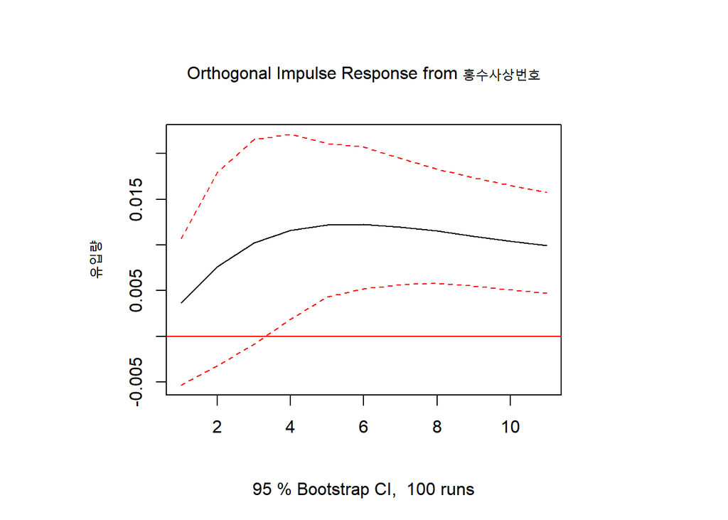

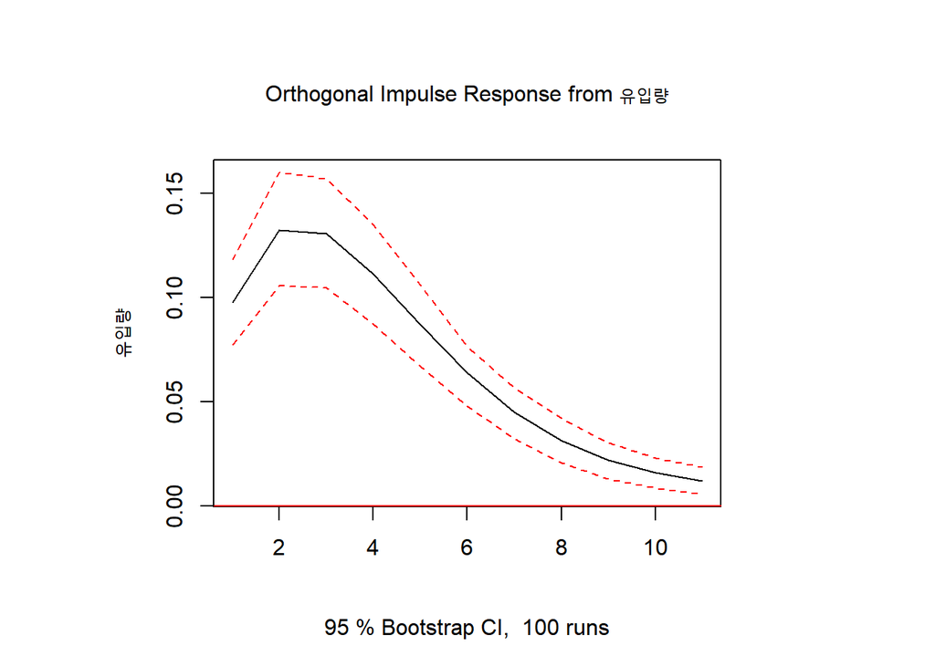

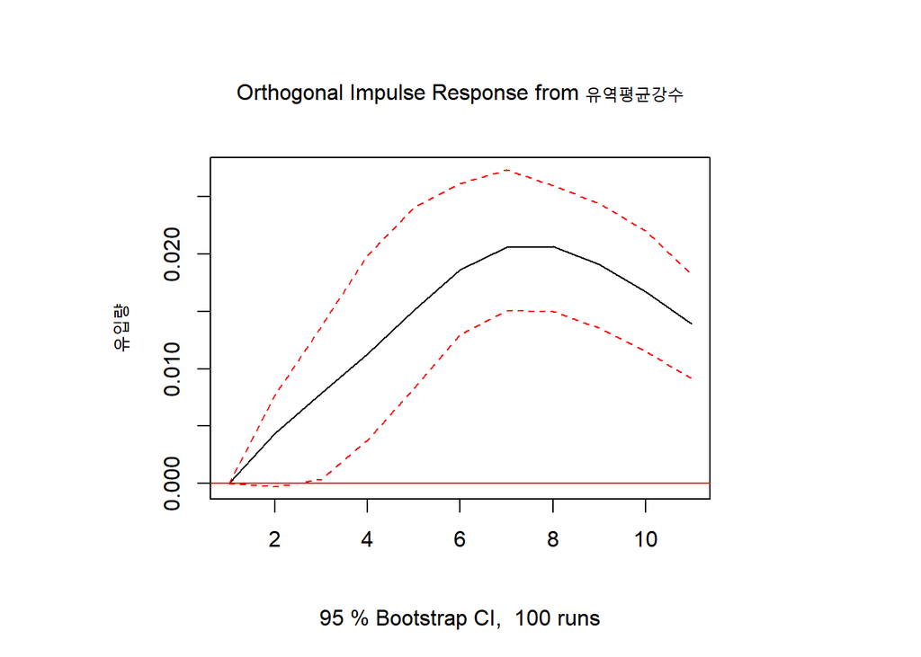

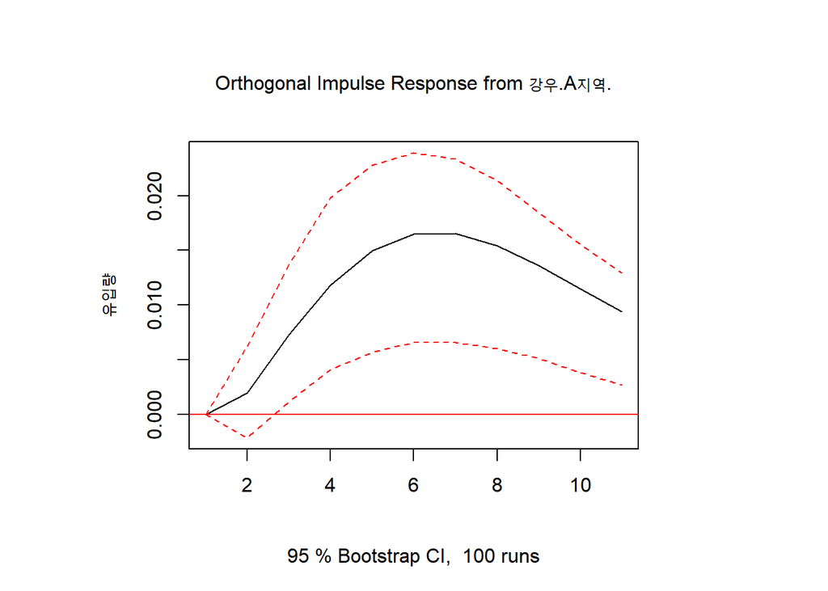

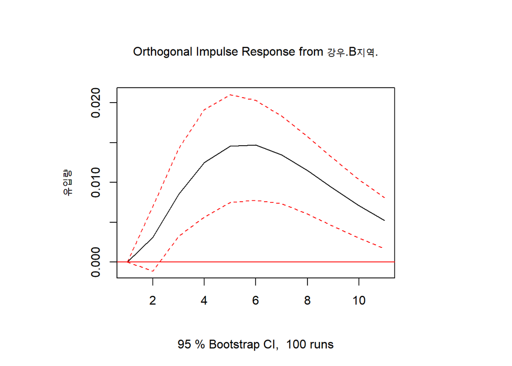

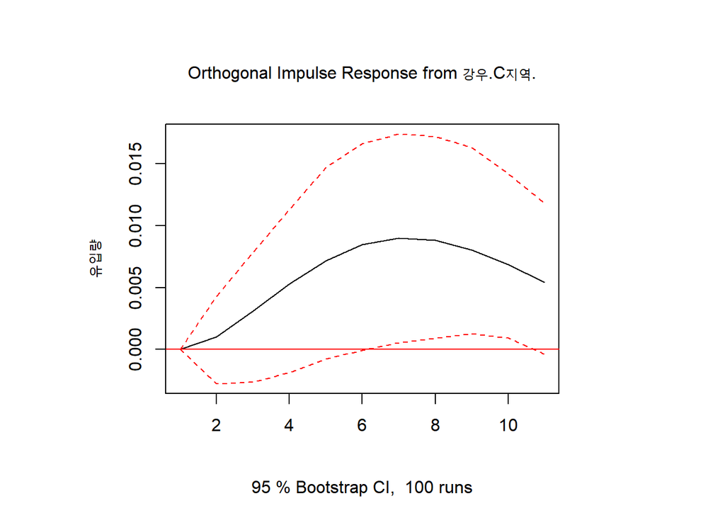

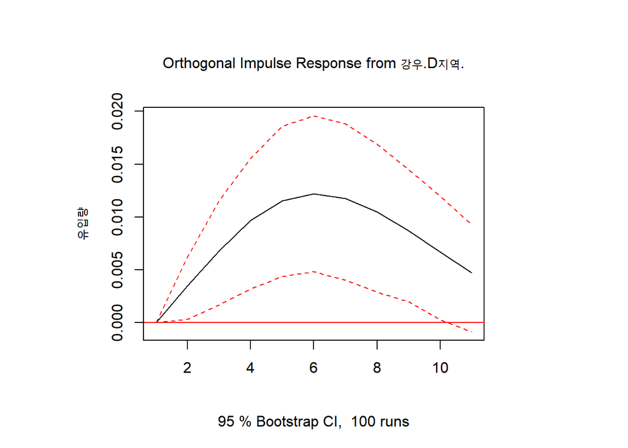

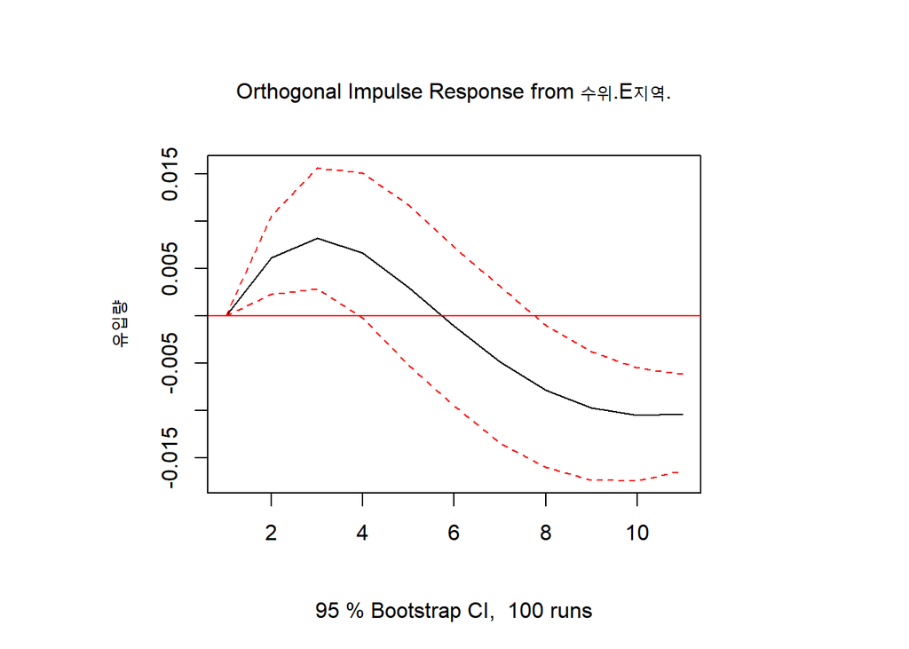

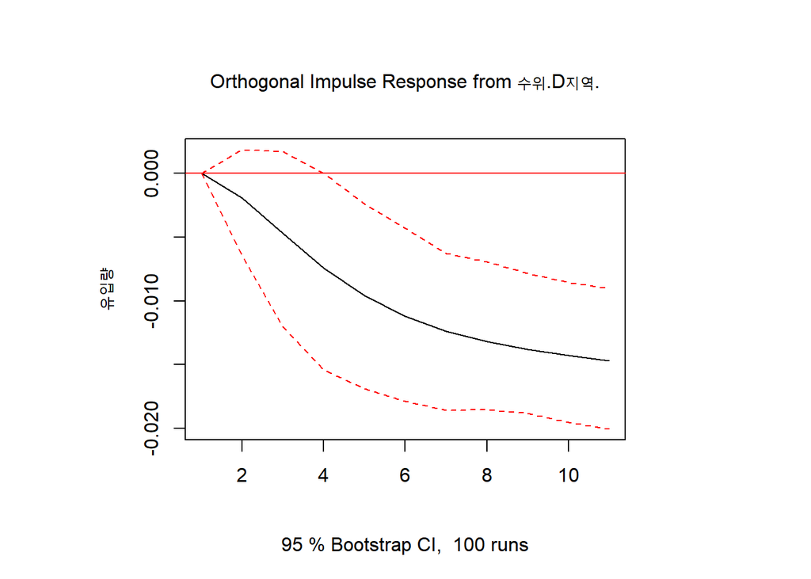

```r
# 충격반응분석
set.seed(1234)
var.irf<-irf(VAR, response = '유입량', boot =TRUE)

# 최적의 시차의 충격반응값 추출
mean_impulse <- var.irf$irf$유역평균강수[5]
preci_A <- var.irf$irf$강우.A지역.[5]
preci_B <- var.irf$irf$강우.B지역.[5]
preci_D <- var.irf$irf$강우.D지역.[5]
level_D <- var.irf$irf$수위.D지역.[5]
level_E <- var.irf$irf$수위.E지역.[3]

# 충격반응함수 플랏
plot(var.irf)
```

[신뢰구간이 0을 포함하지 않으면서 충격반응이 최대가 되는 각 변수별 시차]

1. 유역평균강수 : 8
2. 강우A지역 : 7
3. 강우B지역 : 6
4. 강우C지역 : 7
5. 강우D지역 : 6
6. 수위E지역 : 6시차 이하에선 3시차, 7시차 이상에선 11시차
7. 수위D지역 : 갈수록 증가

하지만 시차를 높게 설정하여 충격변수를 생성한다면 데이터 손실이 크므로 시차 5이상 충격반응이 최대인 변수 중 시차 5에서 신뢰구간이 0을 포함하지 않으면서 시차 5를 충격변수를 생성하기에 최적의 시차로 선정

수위E지역은 6시차 이하에선 3시차에서 가장 충격반응이 크므로 최적의 시차를 3시차로 선정

[충격변수에 사용될 최적의 시차]

1. 유역평균강수 : 5
2. 강우A지역 : 5
3. 강우B지역 : 5
4. 강우D지역 : 5
5. 수위E지역 : 3
6. 수위D지역 : 5

## 충격지속변수 생성

```r
full_data <- bind_rows(pca_train,pca_test)
myList <- list() # 리스트 초기화

for (i in 2:26) {
  origin_frame <- full_data[which(full_data[, "홍수사상번호"] == i), c("홍수사상번호", "유입량","유역평균강수", "강우(A지역)", "강우(B지역)","강우(C지역)", "강우(D지역)", "수위(E지역)","수위(D지역)")]

  store_impulse_mean <- c(NA, diff(origin_frame[, "유역평균강수"], lag = 1)) # 길이 똑같게 하려고 diff한 후 사라진 앞부분 NA로 채워넣음
  store_impulse_mean2 <- store_impulse_mean*mean_impulse
  final_impulse_mean <- shift(store_impulse_mean2, n = 5, fill = NA) #시차 5니까 shift(n=5)

  origin_frame <- cbind(origin_frame, final_impulse_mean)

  store_impulse_preciA <- c(NA, diff(origin_frame[, "강우(A지역)"], lag = 1)) # 길이 똑같게 하려고 diff한 후 사라진 앞부분 NA로 채워넣음
  store_impulse_mean2 <- store_impulse_mean*mean_impulse
  final_impulse_mean <- shift(store_impulse_mean2, n = 5, fill = NA) #시차 5니까 shift(n=5)
  origin_frame <- cbind(origin_frame, final_impulse_mean)

  store_impulse_preciB <- c(NA, diff(origin_frame[, "강우(B지역)"], lag = 1))
  store_impulse_preciB <- store_impulse_preciB*preci_B
  final_impulse_preciB <- shift(store_impulse_preciB, n = 5, fill = NA) # preci_B는 시차 5
  origin_frame <- cbind(origin_frame, final_impulse_preciB)

  store_impulse_preciD <- c(NA, diff(origin_frame[, "강우(D지역)"], lag = 1))
  store_impulse_preciD <- store_impulse_preciD*preci_D
  final_impulse_preciD <- shift(store_impulse_preciD, n = 5, fill = NA) # preci_D는 시차 5
  origin_frame <- cbind(origin_frame, final_impulse_preciD)

  store_impulse_levelE <- c(NA, diff(origin_frame[, "수위(E지역)"], lag = 1))
  store_impulse_levelE <- store_impulse_levelE*level_E
  final_impulse_levelE <- shift(store_impulse_levelE, n = 3, fill = NA) # level_E는 시차 3
  origin_frame <- cbind(origin_frame, final_impulse_levelE)

  store_impulse_levelD <- c(NA, diff(origin_frame[, "수위(D지역)"], lag = 1))
  store_impulse_levelD <- store_impulse_levelD*level_D
  final_impulse_levelD <- shift(store_impulse_levelD, n = 5, fill = NA) # level_D는 시차 5
  origin_frame <- cbind(origin_frame, final_impulse_levelD)

  store_frame <- origin_frame


  colnames(store_frame) <- c("홍수사상번호", "유입량", "유역평균강수", "강우(A지역)", "강우(B지역)", "강우(C지역)",
                             "강우(D지역)", "수위(E지역)", "수위(D지역)", "유역평균강수_충격", "강우A지역_충격",
                             "강우B지역_충격", "강우D지역_충격", "수위E지역_충격", "수위D지역_충격")

  myList[[i]] <- store_frame
}

impulse_frame <- data.frame()

for (i in 2:26) {
  impulse_frame <- rbind(impulse_frame, myList[[i]])
}
```

## 월별변수 생성 - 원핫 인코딩

```r
times <- full_data[,c(1:6)]
final_data <- cbind(times, impulse_frame[,-1])

# 원핫 인코딩
month_select <- final_data[, "월"]
month_select <- month_select %>%
  as.factor %>%
  as.data.frame
colnames(month_select) <- "월"
dmy <- dummyVars(~월, data = month_select)
dummy_var <- data.frame(predict(dmy, newdata = month_select))

# 인코딩 이름을 6월 - 9월로 변경
impulse_PCA_frame <- cbind(final_data, dummy_var) %>%
  as.data.frame
impulse_PCA_frame <- rename(impulse_PCA_frame,
                            c(월.6 = "6월",
                               월.7 = "7월",
                               월.8 = "8월",
                               월.9 = "9월"))

Full_impulse_PCA_frame <- impulse_PCA_frame
Full_impulse_PCA_frame %>% head
```

```
##   홍수사상번호   연 월 일 시간            datetime   유입량 유역평균강수
## 1            2 2006  7 25   24 2006-07-26 00:00:00 323.9933    -2.767803
## 2            2 2006  7 26    1 2006-07-26 01:00:00 323.1541    -2.740128
## 3            2 2006  7 26    2 2006-07-26 02:00:00 293.2403    -2.700166
## 4            2 2006  7 26    3 2006-07-26 03:00:00 261.1777    -2.649192
## 5            2 2006  7 26    4 2006-07-26 04:00:00 256.3884    -2.593454
## 6            2 2006  7 26    5 2006-07-26 05:00:00 279.3519    -2.546115
##   강우(A지역) 강우(B지역) 강우(C지역) 강우(D지역) 수위(E지역) 수위(D지역)
## 1   -2.761784   -2.318442   -2.208967   -2.337439   -1.671494    1.067126
## 2   -2.745307   -2.278834   -2.184418   -2.315893   -1.691717    1.059421
## 3   -2.717766   -2.278834   -2.150756   -2.294348   -1.701829    1.050384
## 4   -2.640794   -2.239226   -2.107974   -2.265577   -1.711940    1.041773
## 5   -2.508567   -2.199617   -2.080773   -2.222433   -1.722051    1.033434
## 6   -2.447658   -2.199617   -2.029023   -2.157744   -1.722051    1.025661
##   유역평균강수_충격 강우A지역_충격 강우B지역_충격 강우D지역_충격 수위E지역_충격
## 1                NA             NA             NA             NA             NA
## 2                NA             NA             NA             NA             NA
## 3                NA             NA             NA             NA             NA
## 4                NA             NA             NA             NA             NA
## 5                NA             NA             NA             NA  -0.0001662382
## 6                NA             NA             NA             NA  -0.0000831191
##   수위D지역_충격 6월 7월 8월 9월
## 1             NA   0   1   0   0
## 2             NA   0   1   0   0
## 3             NA   0   1   0   0
## 4             NA   0   1   0   0
## 5             NA   0   1   0   0
## 6             NA   0   1   0   0
```

## 최종 데이터를 csv로 저장

```r
Full_impulse_PCA_frame %>%
  write.csv("C:/Users/10sop/Desktop/빅콘테스트/Full_impulse_PCA_frame.csv", row.names = FALSE,
            fileEncoding = 'cp949')

Test_impulse_PCA_frame <- impulse_PCA_frame[which(impulse_PCA_frame[, "홍수사상번호"] ==26), ]
rownames(Test_impulse_PCA_frame) <- NULL
Test_impulse_PCA_frame %>% head # 26번 테스트 홍수사상 데이터 %>% head
```

```
##   홍수사상번호   연 월 일 시간            datetime 유입량 유역평균강수
## 1           26 2018  7  1    6 2018-07-01 06:00:00     NA    -2.464289
## 2           26 2018  7  1    7 2018-07-01 07:00:00     NA    -2.472915
## 3           26 2018  7  1    8 2018-07-01 08:00:00     NA    -2.341616
## 4           26 2018  7  1    9 2018-07-01 09:00:00     NA    -2.126982
## 5           26 2018  7  1   10 2018-07-01 10:00:00     NA    -1.853566
## 6           26 2018  7  1   11 2018-07-01 11:00:00     NA    -1.558066
##   강우(A지역) 강우(B지역) 강우(C지역) 강우(D지역) 수위(E지역) 수위(D지역)
## 1   -1.701748  -2.3580503   -2.208967  -2.3374387   -2.682637   -4.628955
## 2   -2.082785  -2.3184421   -1.889835  -2.1650769   -2.682637   -4.630236
## 3   -2.221565  -2.1600093   -1.757978  -1.8203533   -2.692748   -4.631517
## 4   -2.304607  -1.9223600   -1.556733  -1.5686370   -2.692748   -4.632798
## 5   -2.210745  -1.3678452   -1.359102  -1.2734022   -2.692748   -4.633088
## 6   -2.105400  -0.4568565   -1.120478  -0.9568607   -2.662414   -4.632811
##   유역평균강수_충격 강우A지역_충격 강우B지역_충격 강우D지역_충격 수위E지역_충격
## 1                NA             NA             NA             NA             NA
## 2                NA             NA             NA             NA             NA
## 3                NA             NA             NA             NA             NA
## 4                NA             NA             NA             NA             NA
## 5                NA             NA             NA             NA    0.00000e+00
## 6                NA             NA             NA             NA   -8.31191e-05
##   수위D지역_충격 6월 7월 8월 9월
## 1             NA   0   1   0   0
## 2             NA   0   1   0   0
## 3             NA   0   1   0   0
## 4             NA   0   1   0   0
## 5             NA   0   1   0   0
## 6             NA   0   1   0   0
```

```r
Test_impulse_PCA_frame %>%
  write.csv("C:/Users/10sop/Desktop/빅콘테스트/Test_impulse_PCA_frame.csv", row.names = FALSE,
            fileEncoding = 'cp949')
```

# 4. 스태킹 알고리즘

개발한 스태킹 알고리즘에 사용될 데이터프레임을 생성하는 과정

## 학습 데이터용 스태킹 프론트 데이터 생성

```r
for_stacking <- Full_impulse_PCA_frame %>% as.data.table

# 연, 월, 일, 시, datetime 열 삭제
for_stacking <- for_stacking[, -c(2,3,4,5,6)]

# 리스트 초기화
myList <- list()

# 홍수사상별로 리스트에 분리해서 입력
for (i in 2:25) {
  origin_frame <- for_stacking[which(for_stacking[, "홍수사상번호"] == i), c("홍수사상번호", "유입량","유역평균강수", "강우(A지역)", "강우(B지역)",
                                                               "강우(C지역)", "강우(D지역)", "수위(D지역)", "수위(E지역)", "유역평균강수_충격",
                                                               "강우A지역_충격", "강우B지역_충격", "강우D지역_충격", "수위E지역_충격", "수위D지역_충격",
                                                               "6월", "7월", "8월", "9월")]
  myList[[i]] <- origin_frame
}

# 홍수사상 사이에 NA행을 넣어서 하나의 데이터프레임으로 결합
aggregate_frame <- data.frame()
for (i in 2:25) {
  aggregate_frame <- rbind(aggregate_frame, NA, myList[[i]], fill = TRUE)
}

# 결합된 데이터프레임 정리
aggregate_frame <- aggregate_frame[-102,]
aggregate_frame <- subset(aggregate_frame, select = -x)
rmNA_aggregate_frame <- aggregate_frame[complete.cases(aggregate_frame),]

# 차분하지 않을 데이터는 다른 변수에 저장
spare <- rmNA_aggregate_frame[, c("홍수사상번호",
                                  "6월", "7월", "8월", "9월")]

# 홍수사상번호는 따로 저장하여 이후에 차분을 진행한 후 홍수사상의 경계에 존재하는 NA행에 대응되는 행을 spare로 저장해둔 데이터프레임에서 제거할 예정
flood_num <- rmNA_aggregate_frame[, "홍수사상번호"]



# 유역평균강수는 다른 변수들이 1차 차분을 통해 정상화하는 것과 달리 2차 차분을 통해 정상화시켜야 하므로 미리 1차 차분 진행
mean_flood_second_diff <- aggregate_frame[, c("홍수사상번호", "유역평균강수")]
mean_flood_second_diff <- mean_flood_second_diff %>% as.matrix %>% diff

# 홍수사상 사이에 2개의 NA가 생겨야하는데 맨 앞에 NA 한 행 삭제되어서 길이 맞춰주기 위해 NA행 앞에 부착하여 aggregate_frame
mean_flood_second_diff <- rbind(NA, mean_flood_second_diff)
aggregate_frame[,"유역평균강수"] <- mean_flood_second_diff[,"유역평균강수"]

# 모든 변수 차분
flood_diff <- flood_num %>%
  as.matrix %>%
  diff
aggregate_frame <- aggregate_frame %>%
  apply(2, diff)

# aggregate_frame에서 NA행 삭제
aggregate_frame <- aggregate_frame[complete.cases(aggregate_frame), ] %>%
  as.data.frame

# flood_diff 데이터에서 0인 부분은 하나의 홍수사상 내에서 차분된 행 위치, NA인 부분은 서로다른 홍수사상의 데이터끼리 차분된 행 위치를 의미
filter_spare <- spare[which(flood_diff == 0),] %>%
  na.omit %>%
  as.data.frame

filter_spare %>% dim
```

```
## [1] 2497    5
```

```r
aggregate_frame %>% dim
```

```
## [1] 2497   19
```

filter_spare와 aggregate_frame의 행 개수가 같음을 확인할 수 있음

```r
train_front_frame <- cbind(filter_spare[, c("홍수사상번호")],
                           aggregate_frame[, c("유입량","유역평균강수", "강우(A지역)", "강우(B지역)",
                                               "강우(C지역)", "강우(D지역)", "수위(D지역)", "수위(E지역)",
                                               "유역평균강수_충격", "강우A지역_충격", "강우B지역_충격", "강우D지역_충격",
                                               "수위D지역_충격", "수위E지역_충격")],
                           filter_spare[, c("6월", "7월", "8월", "9월")])


colnames(train_front_frame)[1] <- "홍수사상번호"

# 1번 홍수사상은 outlier로 판단하여 삭제
train_front_frame <- train_front_frame[which(train_front_frame[, "홍수사상번호"] != 1),]
train_front_frame %>% head
```

```
##   홍수사상번호    유입량 유역평균강수 강우(A지역) 강우(B지역) 강우(C지역)
## 1            2 34.212180  0.003042551  0.02792326  0.00000000  0.06717962
## 2            2  9.573285  0.030504471  0.00000000  0.07921641  0.10731320
## 3            2  2.613893  0.019004897  0.03295341  0.03960820  0.14993931
## 4            2 15.352758  0.023465294  0.05508297  0.11882461  0.10379038
## 5            2 19.867407 -0.039855950  0.03860626  0.00000000  0.12453035
## 6            2 10.505882 -0.006402573  0.03871079  0.00000000  0.22243894
##   강우(D지역)  수위(D지역) 수위(E지역) 유역평균강수_충격 강우A지역_충격
## 1  0.05037011 -0.009036488  0.00000000      1.859657e-04   1.859657e-04
## 2  0.07183554 -0.008470374  0.00000000      1.666595e-04   1.666595e-04
## 3  0.05031662 -0.007904191  0.00000000      7.210936e-05   7.210936e-05
## 4  0.11500578 -0.007479173  0.02022285     -1.271105e-04  -1.271105e-04
## 5  0.04319743 -0.007206722  0.01011142     -2.925534e-04  -2.925534e-04
## 6  0.10074022 -0.008288564  0.00000000      4.604956e-05   4.604956e-05
##   강우B지역_충격 강우D지역_충격 수위D지역_충격 수위E지역_충격 6월 7월 8월 9월
## 1  -5.765009e-04   0.000000e+00   1.277505e-05    3.64563e-18   0   1   0   0
## 2   5.765009e-04   8.338035e-05  -4.078077e-06    8.31191e-05   0   1   0   0
## 3   1.290201e-17   1.658399e-04  -2.614247e-06    0.00000e+00   0   1   0   0
## 4  -5.765009e-04   2.486030e-04  -5.431837e-06    0.00000e+00   0   1   0   0
## 5   5.765009e-04  -4.972061e-04   4.947850e-06    0.00000e+00   0   1   0   0
## 6  -5.765009e-04   3.319834e-04   7.176376e-06    0.00000e+00   0   1   0   0
```

## 학습 데이터용 스태킹 백 데이터 생성

스태킹 프론트 데이터에서 차분을 통해 소실된 홍수사상별 맨 앞 행 삭제함으로써 스태킹 백 데이터 생성

```r
third <- for_stacking[for_stacking %>% complete.cases(), ]

# 홍수사상별 맨 앞 행 삭제한 후 리스트에 분리해서 입력
for (i in 2:25) {
  third_frame <- third[which(third[, "홍수사상번호"] == i), c("홍수사상번호", "유입량","유역평균강수", "강우(A지역)", "강우(B지역)",
                                                        "강우(C지역)", "강우(D지역)", "수위(D지역)", "수위(E지역)", "유역평균강수_충격",
                                                        "강우A지역_충격", "강우B지역_충격", "강우D지역_충격", "수위D지역_충격", "수위E지역_충격",
                                                        "6월", "7월", "8월", "9월")][-1,]

  myList[[i]] <- third_frame
}

# 하나의 데이터프레임으로 결합
aggregate_frame2 <- data.frame()
for (i in 2:25) {
  aggregate_frame2 <- rbind(aggregate_frame2, myList[[i]])
}

colnames(aggregate_frame2) <- c("홍수사상번호", "유입량","유역평균강수", "강우(A지역)", "강우(B지역)",
                                "강우(C지역)", "강우(D지역)", "수위(D지역)", "수위(E지역)", "유역평균강수_충격",
                                "강우A지역_충격", "강우B지역_충격", "강우D지역_충격", "수위D지역_충격", "수위E지역_충격",
                                "6월", "7월", "8월", "9월")

# NA 행 삭제
train_back_frame <- aggregate_frame2[aggregate_frame2 %>% complete.cases(), ]
train_back_frame %>% head
```

```
##    홍수사상번호   유입량 유역평균강수 강우(A지역) 강우(B지역) 강우(C지역)
## 1:            2 354.0971    -2.487052   -2.397396   -2.160009   -1.943756
## 2:            2 363.6704    -2.425494   -2.397396   -2.080793   -1.836443
## 3:            2 366.2843    -2.344932   -2.364443   -2.041185   -1.686504
## 4:            2 381.6371    -2.240905   -2.309360   -1.922360   -1.582714
## 5:            2 401.5045    -2.176733   -2.270754   -1.922360   -1.458183
## 6:            2 412.0104    -2.118964   -2.232043   -1.922360   -1.235744
##    강우(D지역) 수위(D지역) 수위(E지역) 유역평균강수_충격 강우A지역_충격
## 1:   -2.085775   1.0083358   -1.722051      0.0006048348   0.0006048348
## 2:   -2.013939   0.9998654   -1.722051      0.0007714943   0.0007714943
## 3:   -1.963623   0.9919612   -1.722051      0.0008436036   0.0008436036
## 4:   -1.848617   0.9844820   -1.701829      0.0007164932   0.0007164932
## 5:   -1.805420   0.9772753   -1.691717      0.0004239397   0.0004239397
## 6:   -1.704679   0.9689868   -1.691717      0.0004699893   0.0004699893
##    강우B지역_충격 강우D지역_충격 수위D지역_충격 수위E지역_충격 6월 7월 8월 9월
## 1:   0.0000000000   0.0002486030   8.670565e-05   -8.31191e-05   0   1   0   0
## 2:   0.0005765009   0.0003319834   8.262757e-05    0.00000e+00   0   1   0   0
## 3:   0.0005765009   0.0004978233   8.001332e-05    0.00000e+00   0   1   0   0
## 4:   0.0000000000   0.0007464264   7.458149e-05    0.00000e+00   0   1   0   0
## 5:   0.0005765009   0.0002492203   7.952934e-05    0.00000e+00   0   1   0   0
## 6:   0.0000000000   0.0005812037   8.670571e-05    0.00000e+00   0   1   0   0
```

## 시험 데이터용 스태킹 프론트 데이터 생성

```r
for_stacking_test <- Test_impulse_PCA_frame %>% as.data.table

# 연, 월, 일, 시, datetime 열 삭제
for_stacking_test <- for_stacking_test[, -c(2,3,4,5,6)]

# 차분하지 않을 데이터는 다른 변수에 저장
spare <- for_stacking_test[, c("홍수사상번호",
                     "6월", "7월", "8월", "9월")]

# 유역평균강수는 다른 변수들이 1차 차분을 통해 정상화하는 것과 달리 2차 차분을 통해 정상화시켜야 하므로 미리 1차 차분 진행
for_stacking_test[, "유역평균강수"] <- c(NA, for_stacking_test[,"유역평균강수"] %>%
                                     as.matrix %>%
                                     diff)

# 모든 변수 차분
for_stacking_test <- for_stacking_test %>%
  apply(2, diff)

# for_stacking_test의 첫번째 행이 차분을 통해 삭제되었으므로 spare의 첫번째 행을 삭제
spare <- spare[-1, ]

spare %>% dim
```

```
## [1] 159   5
```

```r
for_stacking_test %>% dim
```

```
## [1] 159  19
```

spare와 for_stacking_test의 행 개수가 같음을 확인할 수 있음

```r
# 하나의 데이터프레임으로 결합
store_frame <- cbind(spare[, c("홍수사상번호")],
                     for_stacking_test[, c("유입량","유역평균강수", "강우(A지역)", "강우(B지역)",
                                 "강우(C지역)", "강우(D지역)", "수위(D지역)", "수위(E지역)",
                                 "유역평균강수_충격", "강우A지역_충격",
                                 "강우B지역_충격", "강우D지역_충격",
                                 "수위D지역_충격", "수위E지역_충격")],
                     spare[, c("6월", "7월", "8월", "9월")])

# 충격변수의 앞 6개 행이 NA이므로 삭제
test_front_frame <- store_frame[-c(1,2,3,4,5,6), ]
test_front_frame %>% head
```

```
##    홍수사상번호 유입량 유역평균강수   강우(A지역) 강우(B지역) 강우(C지역)
## 1:           26     NA  -0.07261789  0.0276460064  0.07921641  0.05425219
## 2:           26     NA  -0.03149353  0.0222340814  0.11882461  0.05175474
## 3:           26     NA   0.02034011 -0.0001727262  0.15843281  0.09158286
## 4:           26     NA   0.10495856  0.3407715842  0.03960820  0.54918307
## 5:           26     NA   0.07453238  0.5560688565  0.11882461  0.23284928
## 6:           26     NA  -0.02994577  0.3149166034  0.11882461  0.38412219
##    강우(D지역)   수위(D지역) 수위(E지역) 유역평균강수_충격 강우A지역_충격
## 1:  0.11497948  2.763438e-04  0.01011142      0.0021178153   0.0021178153
## 2:  0.03591777  5.044797e-05  0.00000000      0.0012612708   0.0012612708
## 3:  0.02167852 -9.070979e-05  0.01011142      0.0008896991   0.0008896991
## 4:  0.26579604 -9.070298e-05  0.15167137      0.0003342222   0.0003342222
## 5:  0.25137000 -9.070298e-05  0.11122567     -0.0017504706  -0.0017504706
## 6:  0.20153305  1.817408e-04  0.16178279     -0.0010990851  -0.0010990851
##    강우B지역_충격 강우D지역_충격 수위D지역_충격 수위E지역_충격 6월 7월 8월 9월
## 1:    0.001729503   0.0019888243   6.535988e-11   0.0000000000   0   1   0   0
## 2:    0.001153002  -0.0010731785  -6.535988e-11   0.0002493573   0   1   0   0
## 3:    0.004612007   0.0005021442  -9.509979e-06  -0.0002493573   0   1   0   0
## 4:    0.005188508   0.0002458510  -5.432430e-06   0.0000831191   0   1   0   0
## 5:   -0.007494512  -0.0019097648  -1.305422e-10  -0.0000831191   0   1   0   0
## 6:   -0.004612007  -0.0004159913  -7.900017e-15   0.0000831191   0   1   0   0
```

## 시험 데이터용 스태킹 백 데이터 생성

```r
third_test <-Test_impulse_PCA_frame %>% as.data.table

# 연, 월, 일, 시, datetime 열 삭제
third_test <- third_test[, -c(2,3,4,5,6)]

# 충격변수의 앞 6개 행이 NA이므로 삭제
test_back_frame <- third_test[-c(1,2,3,4,5,6),]

# test_front_frame의 첫번째 행이 차분을 통해 삭제되었으므로 첫번째 행을 삭제
test_back_frame <- test_back_frame[-1, ]
test_back_frame %>% head
```

```
##    홍수사상번호 유입량 유역평균강수 강우(A지역) 강우(B지역) 강우(C지역)
## 1:           26     NA   -1.2709969  -2.0277016  0.01844192 -0.98491287
## 2:           26     NA   -1.1952647  -2.0054675  0.13726653 -0.93315812
## 3:           26     NA   -1.0991924  -2.0056402  0.29569934 -0.84157526
## 4:           26     NA   -0.8981616  -1.6648686  0.33530755 -0.29239220
## 5:           26     NA   -0.6225983  -1.1087998  0.45413216 -0.05954292
## 6:           26     NA   -0.3769809  -0.7938832  0.57295677  0.32457927
##    강우(D지역) 수위(E지역) 수위(D지역) 유역평균강수_충격 강우A지역_충격
## 1:  -0.6908498   -2.652303   -4.632259       0.001987245    0.001987245
## 2:  -0.6549320   -2.652303   -4.632208       0.003248515    0.003248515
## 3:  -0.6332535   -2.642191   -4.632299       0.004138214    0.004138214
## 4:  -0.3674575   -2.490520   -4.632390       0.004472437    0.004472437
## 5:  -0.1160875   -2.379294   -4.632480       0.002721966    0.002721966
## 6:   0.0854456   -2.217511   -4.632299       0.001622881    0.001622881
##    강우B지역_충격 강우D지역_충격 수위E지역_충격 수위D지역_충격 6월 7월 8월 9월
## 1:    0.002306004    0.003977649   0.0000000000   1.229107e-05   0   1   0   0
## 2:    0.003459005    0.002904470   0.0002493573   1.229100e-05   0   1   0   0
## 3:    0.008071013    0.003406614   0.0000000000   2.781023e-06   0   1   0   0
## 4:    0.013259521    0.003652465   0.0000831191  -2.651407e-06   0   1   0   0
## 5:    0.005765009    0.001742701   0.0000000000  -2.651538e-06   0   1   0   0
## 6:    0.001153002    0.001326709   0.0000831191  -2.651538e-06   0   1   0   0
```

## 최종 스태킹 프론트 데이터, 백 데이터 생성

```r
# Full stacking front dataframe 생성 및 저장
Full_train_stacking_frame <- rbind(train_front_frame, test_front_frame) %>%
  as.data.frame
rownames(Full_train_stacking_frame) <- NULL

# Full stacking back
Full_test_stacking_frame <- rbind(train_back_frame, test_back_frame) %>% as.data.frame
rownames(Full_test_stacking_frame) <- NULL

Full_train_stacking_frame %>% dim
```

```
## [1] 2650   19
```

```r
Full_test_stacking_frame %>% dim
```

```
## [1] 2650   19
```

Full_train_stacking_frame과 Full_test_stacking_frame의 행과 열 개수가 같음을 확인할 수 있음

```r
write.csv(Full_train_stacking_frame, "C:/Users/10sop/Desktop/빅콘테스트/stacking_front_dataframe.csv", row.names = FALSE,
          fileEncoding = 'cp949')

write.csv(Full_test_stacking_frame, "C:/Users/10sop/Desktop/빅콘테스트/stacking_back_dataframe.csv", row.names = FALSE,
          fileEncoding = 'cp949')
```